# Meritocracy and distributive preferences ISSP

jueves 06 agosto 2020 14:08:31

En el presente documento se exponen los análisis realizados a la base de datos creada en data-prep.

En la primera sección se entregan análisis descriptivos de las principales variables dependientes e independientes.

En la segunda sección se exponen los análisis factoriales a partir de los cuales se imputan valores para utilizar en la seccion de analisis multinivel. Además, en la segunda sección se incorpora un análisis de invarianza de medida y una ecuación estructural que resume los modelos a testear.

En la tercera sección se presentan los modelos multinivel que son utilizados para el artículo. Se calcula la correlación intraclase, se evalúan los efectos de las variables nacionales e individuales, para posteriormente evaluar pendientes aleatorias e interacciones entre niveles.

resultados. pese a que la educacion y la sal son formas de redistribucion la gente no lo considera lo mismo.

**Libraries**

```r
library(sjPlot)
library(sjmisc) # several functions,ej read_stata
library(descr)
library(memisc)  # codebook
library(psych) # cor2latex
library(corrplot) # graph correlations
library(lavaan)
library(stargazer)
library(semTools)
library(plyr) # count
library(dplyr)
library(car) # recode
library(ggplot2)
library(Hmisc)
library(tidyverse)
library(data.table)
library(stringr)
library(countrycode)
library(lme4)
library(texreg)
library(mice)
library(ggrepel) # for scatter labels in sjp.scatter
library(semPlot)
library(haven)
library(sjlabelled)
library(kableExtra)
library(ggeffects)
library(influence.ME)
library(lattice)
```

**Load data**

```r
load(file = "input/data/proc/redistrib.rda")
load(file="input/data/proc/mer_pref.rda")
    load("input/data/proc/redistrib.rda")
    load("input/data/proc/getahead.rda")
    load("input/data/proc/detearn.rda")
```

# 1 Descriptives

```r
  # Summary table to latex
    sink("output/results/desctab_red.html")
    stargazer(redistrib[-c(1,2)], type="html"); sink()
```

| Statistic | N | Mean | St. Dev. | Min | Pctl(25) | Pctl(75) | Max |
| --- | --- | --- | --- | --- | --- | --- | --- |
| income_dif | 54,400 | 3.875 | 1.089 | 1.000 | 3.000 | 5.000 | 5.000 |
| unemployed | 54,698 | 3.912 | 0.987 | 1.000 | 3.000 | 5.000 | 5.000 |
| taxes | 53,258 | 4.016 | 0.779 | 1.000 | 4.000 | 5.000 | 5.000 |
| health | 54,237 | 2.464 | 1.312 | 1.000 | 1.000 | 4.000 | 5.000 |
| educ | 54,220 | 2.502 | 1.321 | 1.000 | 1.000 | 4.000 | 5.000 |

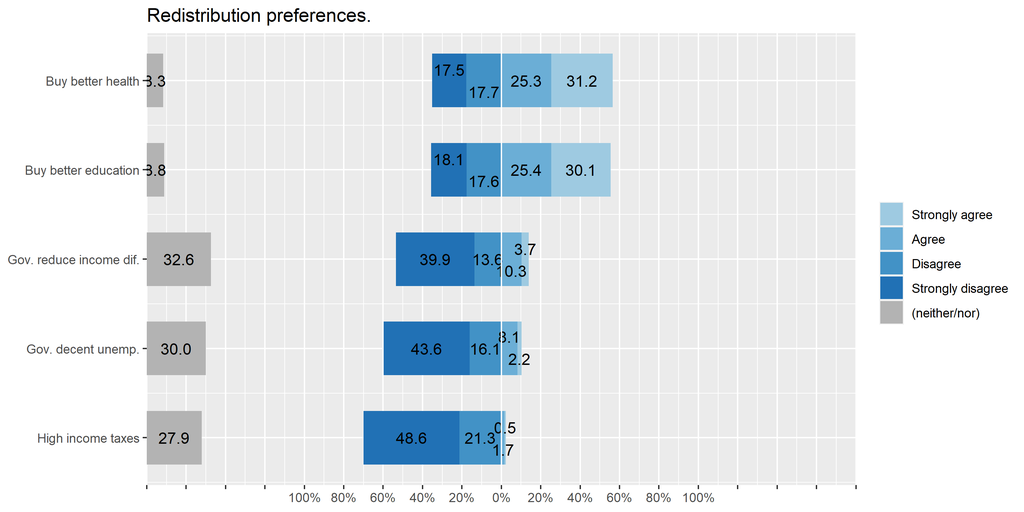

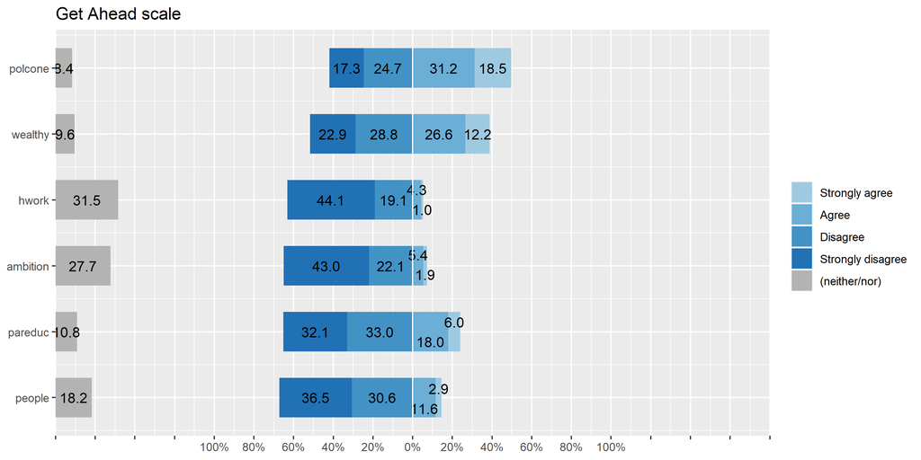

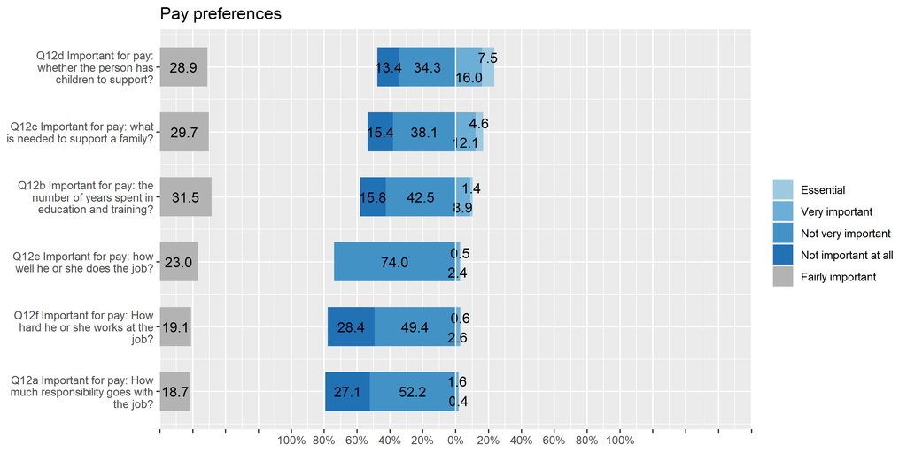

# 2 Modelos de medida

```r
# 4.1 Merge objects --------------------- ----
    load("input/data/proc/redistrib.rda")
    load("input/data/proc/getahead.rda")
    load("input/data/proc/detearn.rda")

    aux1 <- merge(getahead,redistrib,by=c("id","v5"))
  merit_redist=merge(aux1,detearn,by=c("id","v5"))
```

## 2.1 Redistribution preferences.

```r
cfa_red1 <- '
    # latent variables
    redist =~ income_dif + unemployed + taxes
    accum  =~ health + educ
    '
fit_mer_redis <- cfa(cfa_red1,data=merit_redist,
        missing = "ML")
#    summary(fit_mer_red1, fit.measures=TRUE,standardized=TRUE)

fit_mer_redisc <- cfa(cfa_red1,data=merit_redist,
        ordered = names(merit_redist[3:10,19:23]))
    #   summary(fit_mer_redc, fit.measures=TRUE,standardized=TRUE)

fit_mer_redisc_group <- cfa(cfa_red1,data=merit_redist, group = "v5")
#summary(fit_mer_redisc_group, fit.measures=TRUE,standardized=TRUE)

sum_fit<- bind_rows(fitmeasures(fit_mer_redis)[c("chisq","df","cfi","rmsea","rmsea.ci.lower","rmsea.ci.upper")],
                    fitmeasures(fit_mer_redisc)[c("chisq","df","cfi","rmsea","rmsea.ci.lower","rmsea.ci.upper")],
                    fitmeasures(fit_mer_redisc_group)[c("chisq","df","cfi","rmsea","rmsea.ci.lower","rmsea.ci.upper")])

sum_fit$mod <- c("Model 1","Model 2", "Model 3")
sum_fit$est <- c("MLR","DWLS", "MLR")
sum_fit <- sum_fit %>% dplyr::select("mod","est","chisq","df","cfi","rmsea","rmsea.ci.lower","rmsea.ci.upper")



colnames <- c("Model","Estimator","$\\chi2$","df","CFI","RMSEA","RMSEA CI lower", "RMSEA CI upper")

sumtable01<- kable(sum_fit,digits = 3,format = "html",row.names = F,booktabs=T, caption = "Meritocratic belief measurement model summary fit",col.names = colnames,escape = FALSE) %>%
  kable_styling(full_width = F)  %>%
      collapse_rows(columns = 1,valign = "middle")  %>%
      footnote(number = c("Model 1: Continue item",
                          "Model 2: Ordered item",
                          "Model 3: multigroup"));sumtable01
```

| Model | Estimator | $\chi2$ | df | CFI | RMSEA | RMSEA CI lower | RMSEA CI upper |
| --- | --- | --- | --- | --- | --- | --- | --- |
| Model 1 | MLR | 263.419 | 4 | 0.996 | 0.034 | 0.031 | 0.038 |
| Model 2 | DWLS | 363.069 | 4 | 0.999 | 0.043 | 0.039 | 0.046 |
| Model 3 | MLR | 524.217 | 160 | 0.994 | 0.043 | 0.039 | 0.047 |

<sup>1</sup> Model 1: Continue item  
<sup>2</sup> Model 2: Ordered item  
<sup>3</sup> Model 3: multigroup

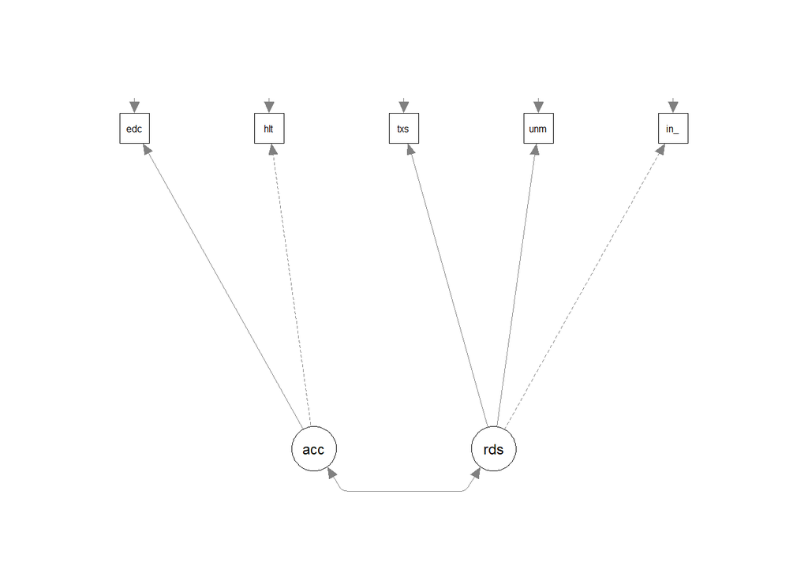

```r
  semPlot::semPaths(fit_mer_redis,layout = "tree", rotation = 3,
                intercepts = FALSE, style = "lisrel", curvePivot = TRUE,
                sizeMan = 4, sizeLat = 6)
```

> A partir del buen ajuste de lo modelos se infiere que la dimensionalidad propuesta posee evidencia de valides. No existe gran diferencia entre los resultados de los distintos estimadores. Podemos decir ademas, en función del modelo que incluye grupos, que esta dimensionalidad funciona en distintos países.

```r
# por paises
merit_redist_arg<-  merit_redist %>% filter(v5==32)
fit_mer_redis_arg <- cfa(cfa_red1,data=merit_redist_arg,missing = "ML" , estimator="MLR")
merit_redist_australia<-  merit_redist %>% filter(v5==36)
fit_mer_redis_australia <- cfa(cfa_red1,data=merit_redist_australia,missing = "ML" , estimator="MLR")
merit_redist_austria<-  merit_redist %>% filter(v5==40)
fit_mer_redis_austria <- cfa(cfa_red1,data=merit_redist_austria,missing = "ML" , estimator="MLR")
merit_redist_belgium<-  merit_redist %>% filter(v5==56)
fit_mer_redis_belgium <- cfa(cfa_red1,data=merit_redist_belgium,missing = "ML" , estimator="MLR")
merit_redist_bulgaria<-  merit_redist %>% filter(v5==100)
fit_mer_redis_bulgaria <- cfa(cfa_red1,data=merit_redist_bulgaria,missing = "ML" , estimator="MLR")
merit_redist_chile<-  merit_redist %>% filter(v5==152)
fit_mer_redis_chile <- cfa(cfa_red1,data=merit_redist_chile,missing = "ML" , estimator="MLR")
merit_redist_china <-  merit_redist %>% filter(v5==156)
fit_mer_redis_china <- cfa(cfa_red1,data=merit_redist_china,missing = "ML" , estimator="MLR")
merit_redist_taiwan <-  merit_redist %>% filter(v5==158)
fit_mer_redis_taiwan <- cfa(cfa_red1,data=merit_redist_taiwan,missing = "ML" , estimator="MLR")
merit_redist_croatia <-  merit_redist %>% filter(v5==191)
fit_mer_redis_croatia <- cfa(cfa_red1,data=merit_redist_croatia,missing = "ML" , estimator="MLR")


#merit_redist_cyprus <-  merit_redist %>% filter(v5==196)
#fit_mer_redis_cyprus <- cfa(cfa_red1,data=merit_redist_cyprus,missing = "ML" , estimator="MLR")

#merit_redist_cyprus <-  merit_redist %>% filter(v5==196)
#fit_mer_redis_cyprus <- cfa(cfa_red1,data=merit_redist_cyprus, ordered = names(merit_redist[3:10,19:23]))


merit_redist_chequia <-  merit_redist %>% filter(v5==203)
fit_mer_redis_chequia <- cfa(cfa_red1,data=merit_redist_chequia,missing = "ML" , estimator="MLR")
merit_redist_denmark <-  merit_redist %>% filter(v5==208)
fit_mer_redis_denmark <- cfa(cfa_red1,data=merit_redist_denmark,missing = "ML" , estimator="MLR")
merit_redist_est <-  merit_redist %>% filter(v5==233)
fit_mer_redis_est <- cfa(cfa_red1,data=merit_redist_est,missing = "ML" , estimator="MLR")
merit_redist_finlandia <-  merit_redist %>% filter(v5==246)
fit_mer_redis_finlandia <- cfa(cfa_red1,data=merit_redist_finlandia,missing = "ML" , estimator="MLR")
merit_redist_francia <-  merit_redist %>% filter(v5==250)
fit_mer_redis_francia <- cfa(cfa_red1,data=merit_redist_francia,missing = "ML" , estimator="MLR")
merit_redist_deutschland <-  merit_redist %>% filter(v5==276)
fit_mer_redis_deutschland <- cfa(cfa_red1,data=merit_redist_deutschland,missing = "ML" , estimator="MLR")
merit_redist_hunria <-  merit_redist %>% filter(v5==348)
fit_mer_redis_hunria <- cfa(cfa_red1,data=merit_redist_hunria,missing = "ML" , estimator="MLR")
merit_redist_islandia <-  merit_redist %>% filter(v5==352)
fit_mer_redis_islandia <- cfa(cfa_red1,data=merit_redist_islandia,missing = "ML" , estimator="MLR")
merit_redist_israel <-  merit_redist %>% filter(v5==376)
fit_mer_redis_israel <- cfa(cfa_red1,data=merit_redist_israel,missing = "ML" , estimator="MLR")
merit_redist_italia <-  merit_redist %>% filter(v5==380)
fit_mer_redis_italia <- cfa(cfa_red1,data=merit_redist_italia,missing = "ML" , estimator="MLR")
merit_redist_japon <-  merit_redist %>% filter(v5==392)
fit_mer_redis_japon <- cfa(cfa_red1,data=merit_redist_japon,missing = "ML" , estimator="MLR")
merit_redist_letonia <-  merit_redist %>% filter(v5==428)
fit_mer_redis_letonia <- cfa(cfa_red1,data=merit_redist_letonia,missing = "ML" , estimator="MLR")
merit_redist_lituania <-  merit_redist %>% filter(v5==440)
fit_mer_redis_lituania <- cfa(cfa_red1,data=merit_redist_lituania,missing = "ML" , estimator="MLR")
merit_redist_nuevazelanda <-  merit_redist %>% filter(v5==554)
fit_mer_redis_nuevazelanda <- cfa(cfa_red1,data=merit_redist_nuevazelanda,missing = "ML" , estimator="MLR")
merit_redist_noruega <-  merit_redist %>% filter(v5==578)
fit_mer_redis_noruega <- cfa(cfa_red1,data=merit_redist_noruega,missing = "ML" , estimator="MLR")
merit_redist_filipinas <-  merit_redist %>% filter(v5==608)
fit_mer_redis_filipinas <- cfa(cfa_red1,data=merit_redist_filipinas,missing = "ML" , estimator="MLR")
merit_redist_polonia <-  merit_redist %>% filter(v5==616)
fit_mer_redis_polonia <- cfa(cfa_red1,data=merit_redist_polonia,missing = "ML" , estimator="MLR")
merit_redist_rusia <-  merit_redist %>% filter(v5==643)
fit_mer_redis_rusia <- cfa(cfa_red1,data=merit_redist_rusia,missing = "ML" , estimator="MLR")
merit_redist_eslovaquia <-  merit_redist %>% filter(v5==703)
fit_mer_redis_eslovaquia <- cfa(cfa_red1,data=merit_redist_eslovaquia,missing = "ML" , estimator="MLR")
merit_redist_eslovenia <-  merit_redist %>% filter(v5==705)
fit_mer_redis_eslovenia <- cfa(cfa_red1,data=merit_redist_eslovenia,missing = "ML" , estimator="MLR")
merit_redist_sudafrica <-  merit_redist %>% filter(v5==710)
fit_mer_redis_sudafrica <- cfa(cfa_red1,data=merit_redist_sudafrica,missing = "ML" , estimator="MLR")
merit_redist_sudafrica <-  merit_redist %>% filter(v5==710)
fit_mer_redis_sudafrica <- cfa(cfa_red1,data=merit_redist_sudafrica,missing = "ML" , estimator="MLR")
merit_redist_espana <-  merit_redist %>% filter(v5==724)
fit_mer_redis_espana <- cfa(cfa_red1,data=merit_redist_espana,missing = "ML" , estimator="MLR")
merit_redist_suecia <-  merit_redist %>% filter(v5==752)
fit_mer_redis_suecia <- cfa(cfa_red1,data=merit_redist_suecia,missing = "ML" , estimator="MLR")
merit_redist_suiza <-  merit_redist %>% filter(v5==756)
fit_mer_redis_suiza <- cfa(cfa_red1,data=merit_redist_suiza,missing = "ML" , estimator="MLR")
merit_redist_turquia<-  merit_redist %>% filter(v5==792)
fit_mer_redis_turquia <- cfa(cfa_red1,data=merit_redist_turquia,missing = "ML" , estimator="MLR")
merit_redist_ucrania<-  merit_redist %>% filter(v5==804)
fit_mer_redis_ucrania <- cfa(cfa_red1,data=merit_redist_ucrania,missing = "ML" , estimator="MLR")
merit_redist_reinounido<-  merit_redist %>% filter(v5==826)
fit_mer_redis_reinounido <- cfa(cfa_red1,data=merit_redist_reinounido,missing = "ML" , estimator="MLR")
merit_redist_estadosunidos<-  merit_redist %>% filter(v5==840)
fit_mer_redis_estadosunidos <- cfa(cfa_red1,data=merit_redist_estadosunidos,missing = "ML" , estimator="MLR")
```

```r
#merit_redist_venezuela<-  merit_redist %>% filter(v5==862)
#fit_mer_redis_venezuela <- cfa(cfa_red1,data=merit_redist_venezuela,missing = "ML")


#merit_redist_venezuela<-  merit_redist %>% filter(v5==862)
#fit_mer_redis_venezuela <- cfa(cfa_red1,data=merit_redist_venezuela,ordered = names(merit_redist[3:10,19:23]))


sum_fit<- bind_rows(fitmeasures(fit_mer_redis_arg)[c("chisq","df","cfi.robust","rmsea.robust","rmsea.ci.lower.robust","rmsea.ci.upper.robust")],
                    fitmeasures(fit_mer_redis_australia)[c("chisq","df","cfi.robust","rmsea.robust","rmsea.ci.lower.robust","rmsea.ci.upper.robust")],
                    fitmeasures(fit_mer_redis_austria)[c("chisq","df","cfi.robust","rmsea.robust","rmsea.ci.lower.robust","rmsea.ci.upper.robust")],
                    fitmeasures(fit_mer_redis_belgium)[c("chisq","df","cfi.robust","rmsea.robust","rmsea.ci.lower.robust","rmsea.ci.upper.robust")],
                    fitmeasures(fit_mer_redis_bulgaria)[c("chisq","df","cfi.robust","rmsea.robust","rmsea.ci.lower.robust","rmsea.ci.upper.robust")],
                    fitmeasures(fit_mer_redis_chile)[c("chisq","df","cfi.robust","rmsea.robust","rmsea.ci.lower.robust","rmsea.ci.upper.robust")],
                    fitmeasures(fit_mer_redis_china)[c("chisq","df","cfi.robust","rmsea.robust","rmsea.ci.lower.robust","rmsea.ci.upper.robust")],
                    fitmeasures(fit_mer_redis_taiwan)[c("chisq","df","cfi.robust","rmsea.robust","rmsea.ci.lower.robust","rmsea.ci.upper.robust")],
                    fitmeasures(fit_mer_redis_croatia)[c("chisq","df","cfi.robust","rmsea.robust","rmsea.ci.lower.robust","rmsea.ci.upper.robust")],
#                   fitmeasures(fit_mer_redis_cyprus)[c("chisq","df","cfi.robust","rmsea.robust","rmsea.ci.lower.robust","rmsea.ci.upper.robust")],
                    fitmeasures(fit_mer_redis_chequia)[c("chisq","df","cfi.robust","rmsea.robust","rmsea.ci.lower.robust","rmsea.ci.upper.robust")],
                    fitmeasures(fit_mer_redis_denmark)[c("chisq","df","cfi.robust","rmsea.robust","rmsea.ci.lower.robust","rmsea.ci.upper.robust")],
                    fitmeasures(fit_mer_redis_est)[c("chisq","df","cfi.robust","rmsea.robust","rmsea.ci.lower.robust","rmsea.ci.upper.robust")],
                    fitmeasures(fit_mer_redis_finlandia)[c("chisq","df","cfi.robust","rmsea.robust","rmsea.ci.lower.robust","rmsea.ci.upper.robust")],
                    fitmeasures(fit_mer_redis_francia)[c("chisq","df","cfi.robust","rmsea.robust","rmsea.ci.lower.robust","rmsea.ci.upper.robust")],
                    fitmeasures(fit_mer_redis_deutschland)[c("chisq","df","cfi.robust","rmsea.robust","rmsea.ci.lower.robust","rmsea.ci.upper.robust")],
#                   fitmeasures(fit_mer_redis_venezuela)[c("chisq","df","cfi.robust","rmsea.robust","rmsea.ci.lower.robust","rmsea.ci.upper.robust")],
                    fitmeasures(fit_mer_redis_islandia)[c("chisq","df","cfi.robust","rmsea.robust","rmsea.ci.lower.robust","rmsea.ci.upper.robust")],
                    fitmeasures(fit_mer_redis_israel)[c("chisq","df","cfi.robust","rmsea.robust","rmsea.ci.lower.robust","rmsea.ci.upper.robust")],
                    fitmeasures(fit_mer_redis_italia)[c("chisq","df","cfi.robust","rmsea.robust","rmsea.ci.lower.robust","rmsea.ci.upper.robust")],
                    fitmeasures(fit_mer_redis_japon)[c("chisq","df","cfi.robust","rmsea.robust","rmsea.ci.lower.robust","rmsea.ci.upper.robust")],
                    fitmeasures(fit_mer_redis_letonia)[c("chisq","df","cfi.robust","rmsea.robust","rmsea.ci.lower.robust","rmsea.ci.upper.robust")],
                    fitmeasures(fit_mer_redis_lituania)[c("chisq","df","cfi.robust","rmsea.robust","rmsea.ci.lower.robust","rmsea.ci.upper.robust")],
                    fitmeasures(fit_mer_redis_nuevazelanda)[c("chisq","df","cfi.robust","rmsea.robust","rmsea.ci.lower.robust","rmsea.ci.upper.robust")],
                    fitmeasures(fit_mer_redis_noruega)[c("chisq","df","cfi.robust","rmsea.robust","rmsea.ci.lower.robust","rmsea.ci.upper.robust")],
                    fitmeasures(fit_mer_redis_filipinas)[c("chisq","df","cfi.robust","rmsea.robust","rmsea.ci.lower.robust","rmsea.ci.upper.robust")],
                    fitmeasures(fit_mer_redis_polonia)[c("chisq","df","cfi.robust","rmsea.robust","rmsea.ci.lower.robust","rmsea.ci.upper.robust")],
                    fitmeasures(fit_mer_redis_rusia)[c("chisq","df","cfi.robust","rmsea.robust","rmsea.ci.lower.robust","rmsea.ci.upper.robust")],
                    fitmeasures(fit_mer_redis_eslovaquia)[c("chisq","df","cfi.robust","rmsea.robust","rmsea.ci.lower.robust","rmsea.ci.upper.robust")],
                    fitmeasures(fit_mer_redis_eslovenia)[c("chisq","df","cfi.robust","rmsea.robust","rmsea.ci.lower.robust","rmsea.ci.upper.robust")],
                    fitmeasures(fit_mer_redis_sudafrica)[c("chisq","df","cfi.robust","rmsea.robust","rmsea.ci.lower.robust","rmsea.ci.upper.robust")],
                    fitmeasures(fit_mer_redis_espana)[c("chisq","df","cfi.robust","rmsea.robust","rmsea.ci.lower.robust","rmsea.ci.upper.robust")],
                    fitmeasures(fit_mer_redis_suecia)[c("chisq","df","cfi.robust","rmsea.robust","rmsea.ci.lower.robust","rmsea.ci.upper.robust")],
                    fitmeasures(fit_mer_redis_suiza)[c("chisq","df","cfi.robust","rmsea.robust","rmsea.ci.lower.robust","rmsea.ci.upper.robust")],
                    fitmeasures(fit_mer_redis_turquia)[c("chisq","df","cfi.robust","rmsea.robust","rmsea.ci.lower.robust","rmsea.ci.upper.robust")],
                    fitmeasures(fit_mer_redis_ucrania)[c("chisq","df","cfi.robust","rmsea.robust","rmsea.ci.lower.robust","rmsea.ci.upper.robust")],
                    fitmeasures(fit_mer_redis_reinounido)[c("chisq","df","cfi.robust","rmsea.robust","rmsea.ci.lower.robust","rmsea.ci.upper.robust")],
                    fitmeasures(fit_mer_redis_estadosunidos)[c("chisq","df","cfi.robust","rmsea.robust","rmsea.ci.lower.robust","rmsea.ci.upper.robust")])

sum_fit$mod <- c("Argentina","Australia","Austria", "Belguim","Bulgaria","Chile","China","Taiwan", "Croatia", "Chequia","Dinamarca","EST","Finlandia","Francia","Deutschland", "Islandia", "Israel","Italia", "Japon", "Letonia","Lituania","Nueva Zelanda", "Noruega", "Filipinas", "Polonia", "Rusia","Eslovequia","Eslovenia","Sudafrica", "España","Suecia","Suiza","Truquia","Ucrania","Reino Unido", "Estados Unidos.")
```

```r
colnames <- c("Model","$\\chi2$","df","CFI","RMSEA","RMSEA CI lower", "RMSEA CI upper")
      sum_fit <- sum_fit %>% dplyr::select("mod","chisq","df","cfi.robust","rmsea.robust","rmsea.ci.lower.robust","rmsea.ci.upper.robust")
sumtable01<- kable(sum_fit,digits = 3,format = "html",row.names = F,booktabs=T, caption = "Summary fit  countries",col.names = colnames,escape = FALSE) %>%
  kable_styling(full_width = F)  %>%
      collapse_rows(columns = 1,valign = "middle");sumtable01
```

Summary fit countries

| Model | $\chi2$ | df | CFI | RMSEA | RMSEA CI lower | RMSEA CI upper |
| --- | --- | --- | --- | --- | --- | --- |
| Argentina | 14.656 | 4 | 0.988 | 0.048 | 0.021 | 0.077 |
| Australia | 4.770 | 4 | 1.000 | 0.006 | 0.000 | 0.043 |
| Austria | 13.295 | 4 | 0.993 | 0.045 | 0.013 | 0.079 |
| Belguim | 4.290 | 4 | 1.000 | 0.006 | 0.000 | 0.047 |
| Bulgaria | 34.641 | 4 | 0.976 | 0.088 | 0.062 | 0.117 |
| Chile | 27.996 | 4 | 0.988 | 0.062 | 0.039 | 0.088 |
| China | 10.529 | 4 | 0.998 | 0.021 | 0.000 | 0.042 |
| Taiwan | 7.311 | 4 | 0.998 | 0.019 | 0.000 | 0.044 |
| Croatia | 4.449 | 4 | 1.000 | 0.000 | 0.000 | 0.046 |
| Chequia | 20.579 | 4 | 0.993 | 0.058 | 0.033 | 0.086 |
| Dinamarca | 3.204 | 4 | 1.000 | 0.000 | 0.000 | 0.035 |
| EST | 1.645 | 4 | 1.000 | 0.000 | 0.000 | 0.029 |
| Finlandia | 9.239 | 4 | 0.996 | 0.037 | 0.000 | 0.072 |
| Francia | 2.443 | 4 | 1.000 | 0.000 | 0.000 | 0.023 |
| Deutschland | 9.020 | 4 | 0.997 | 0.029 | 0.000 | 0.057 |
| Islandia | 0.783 | 4 | 1.000 | 0.000 | 0.000 | 0.000 |
| Israel | 39.497 | 4 | 0.982 | 0.087 | 0.067 | 0.109 |
| Italia | 3.063 | 4 | 1.000 | 0.000 | 0.000 | 0.041 |
| Japon | 7.560 | 4 | 0.998 | 0.025 | 0.000 | 0.056 |
| Letonia | 20.557 | 4 | 0.991 | 0.061 | 0.034 | 0.091 |
| Lituania | 0.947 | 4 | 1.000 | 0.000 | 0.000 | 0.014 |
| Nueva Zelanda | 5.055 | 4 | 0.999 | 0.017 | 0.000 | 0.055 |
| Noruega | 5.328 | 4 | 1.000 | 0.011 | 0.000 | 0.049 |
| Filipinas | 10.865 | 4 | 0.988 | 0.040 | 0.017 | 0.065 |
| Polonia | 19.287 | 4 | 0.992 | 0.052 | 0.025 | 0.083 |
| Rusia | 17.010 | 4 | 0.993 | 0.043 | 0.020 | 0.070 |
| Eslovequia | 42.995 | 4 | 0.977 | 0.091 | 0.067 | 0.118 |
| Eslovenia | 15.182 | 4 | 0.988 | 0.048 | 0.016 | 0.082 |
| Sudafrica | 5.139 | 4 | 1.000 | 0.008 | 0.000 | 0.030 |
| España | 12.669 | 4 | 0.996 | 0.040 | 0.007 | 0.071 |
| Suecia | 4.819 | 4 | 1.000 | 0.000 | 0.000 | 0.049 |
| Suiza | 1.017 | 4 | 1.000 | 0.000 | 0.000 | 0.015 |
| Truquia | 45.873 | 4 | 0.976 | 0.081 | 0.059 | 0.106 |
| Ucrania | 31.356 | 4 | 0.992 | 0.056 | 0.032 | 0.082 |
| Reino Unido | 5.535 | 4 | 1.000 | 0.013 | 0.000 | 0.057 |
| Estados Unidos. | 3.686 | 4 | 1.000 | 0.000 | 0.000 | 0.037 |

> El modelo no converge ni en Chipre ni en Venezuela (ni utilizando ordinales)

## 2.2 Meritocratic beliefs

```r
      cfa_perpref2 <- '
      # latent variables
      merit =~ hwork + ambition
      parent=~ wealthy + pareduc
      backg=~ race + gender
        network=~ people + polcone
        unmerit=~ parent + backg + network # 2nd order
      bmerit =~ welljob + hardjob
      need=~ family + child
        '

fit_mer_mer <- cfa(cfa_perpref2,data=merit_redist,
        missing = "ML")
#    summary(fit_mer_red1, fit.measures=TRUE,standardized=TRUE)

fit_mer_merc <- cfa(cfa_perpref2,data=merit_redist,
        ordered = names(merit_redist[3:10,19:23]))
    #   summary(fit_mer_redc, fit.measures=TRUE,standardized=TRUE)

fit_mer_mer_group <- cfa(cfa_perpref2,data=merit_redist, group = "v5")
#summary(fit_mer_redisc_group, fit.measures=TRUE,standardized=TRUE)



sum_fit<- bind_rows(fitmeasures(fit_mer_mer)[c("chisq","df","cfi","rmsea","rmsea.ci.lower","rmsea.ci.upper")],
                    fitmeasures(fit_mer_merc)[c("chisq","df","cfi","rmsea","rmsea.ci.lower","rmsea.ci.upper")],
                    fitmeasures(fit_mer_mer_group)[c("chisq","df","cfi","rmsea","rmsea.ci.lower","rmsea.ci.upper")])

sum_fit$mod <- c("Model 1","Model 2", "Model 3")
sum_fit$est <- c("MLR","DWLS", "MLR")
sum_fit <- sum_fit %>% dplyr::select("mod","est","chisq","df","cfi","rmsea","rmsea.ci.lower","rmsea.ci.upper")



colnames <- c("Model","Estimator","$\\chi2$","df","CFI","RMSEA","RMSEA CI lower", "RMSEA CI upper")

sumtable01<- kable(sum_fit,digits = 3,format = "html",row.names = F,booktabs=T, caption = "Redistribution measurement model summary fit",col.names = colnames,escape = FALSE) %>%
  kable_styling(full_width = F)  %>%
      collapse_rows(columns = 1,valign = "middle")  %>%
      footnote(number = c("Model 1: Continue item",
                          "Model 2: Ordered item",
                          "Model 3: multigroup"));sumtable01
```

| Model | Estimator | $\chi2$ | df | CFI | RMSEA | RMSEA CI lower | RMSEA CI upper |
| --- | --- | --- | --- | --- | --- | --- | --- |
| Model 1 | MLR | 4008.328 | 45 | 0.971 | 0.040 | 0.039 | 0.041 |
| Model 2 | DWLS | 1677.913 | 45 | 0.979 | 0.034 | 0.032 | 0.035 |
| Model 3 | MLR | 6019.790 | 1800 | 0.946 | 0.054 | 0.053 | 0.056 |

<sup>1</sup> Model 1: Continue item  
<sup>2</sup> Model 2: Ordered item  
<sup>3</sup> Model 3: multigroup

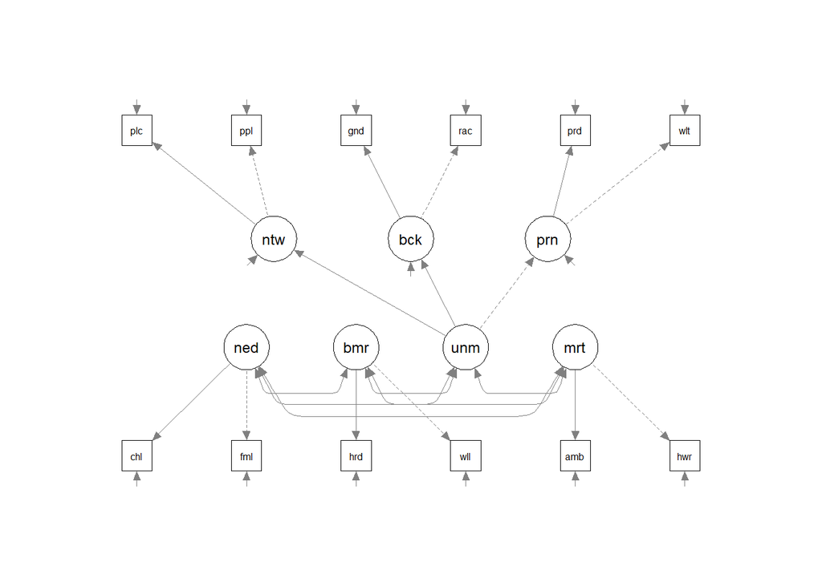

```r
  semPlot::semPaths(fit_mer_mer,layout = "tree", rotation = 3,
                intercepts = FALSE, style = "lisrel", curvePivot = TRUE,
                sizeMan = 4, sizeLat = 6)
```

> A partir del buen ajuste de los modelos se infiere que la dimensionalidad propuesta posee evidencia de valides. No existe gran diferencia entre los resultados de los distintos estimadores. Podemos decir ademas, en función del modelo que incluye grupos, que esta dimensionalidad funciona en distintos países.

```r
# por paises
merit_redist_arg<-  merit_redist %>% filter(v5==32)
fit_mer_redis_arg <- cfa(cfa_perpref2,data=merit_redist_arg,missing = "ML" , estimator="MLR" )
merit_redist_australia<-  merit_redist %>% filter(v5==36)
fit_mer_redis_australia <- cfa(cfa_perpref2,data=merit_redist_australia,missing = "ML" , estimator="MLR")
merit_redist_austria<-  merit_redist %>% filter(v5==40)
fit_mer_redis_austria <- cfa(cfa_perpref2,data=merit_redist_austria,missing = "ML" , estimator="MLR")
merit_redist_belgium<-  merit_redist %>% filter(v5==56)
fit_mer_redis_belgium <- cfa(cfa_perpref2,data=merit_redist_belgium,missing = "ML" , estimator="MLR")
merit_redist_bulgaria<-  merit_redist %>% filter(v5==100)
fit_mer_redis_bulgaria <- cfa(cfa_perpref2,data=merit_redist_bulgaria,missing = "ML" , estimator="MLR")
merit_redist_chile<-  merit_redist %>% filter(v5==152)
fit_mer_redis_chile <- cfa(cfa_perpref2,data=merit_redist_chile,missing = "ML" , estimator="MLR")
merit_redist_china <-  merit_redist %>% filter(v5==156)
fit_mer_redis_china <- cfa(cfa_perpref2,data=merit_redist_china,missing = "ML" , estimator="MLR")
merit_redist_taiwan <-  merit_redist %>% filter(v5==158)
fit_mer_redis_taiwan <- cfa(cfa_perpref2,data=merit_redist_taiwan,missing = "ML" , estimator="MLR")
merit_redist_croatia <-  merit_redist %>% filter(v5==191)
fit_mer_redis_croatia <- cfa(cfa_perpref2,data=merit_redist_croatia,missing = "ML" , estimator="MLR")
merit_redist_cyprus <-  merit_redist %>% filter(v5==196)
fit_mer_redis_cyprus <- cfa(cfa_perpref2,data=merit_redist_cyprus,missing = "ML" , estimator="MLR")
merit_redist_chequia <-  merit_redist %>% filter(v5==203)
fit_mer_redis_chequia <- cfa(cfa_perpref2,data=merit_redist_chequia,missing = "ML" , estimator="MLR")
merit_redist_denmark <-  merit_redist %>% filter(v5==208)
fit_mer_redis_denmark <- cfa(cfa_perpref2,data=merit_redist_denmark,missing = "ML" , estimator="MLR")
merit_redist_est <-  merit_redist %>% filter(v5==233)
fit_mer_redis_est <- cfa(cfa_perpref2,data=merit_redist_est,missing = "ML" , estimator="MLR")
merit_redist_finlandia <-  merit_redist %>% filter(v5==246)
fit_mer_redis_finlandia <- cfa(cfa_perpref2,data=merit_redist_finlandia,missing = "ML" , estimator="MLR")
merit_redist_francia <-  merit_redist %>% filter(v5==250)
fit_mer_redis_francia <- cfa(cfa_perpref2,data=merit_redist_francia,missing = "ML" , estimator="MLR")
merit_redist_deutschland <-  merit_redist %>% filter(v5==276)
fit_mer_redis_deutschland <- cfa(cfa_perpref2,data=merit_redist_deutschland,missing = "ML" , estimator="MLR")
merit_redist_hunria <-  merit_redist %>% filter(v5==348)
fit_mer_redis_hunria <- cfa(cfa_perpref2,data=merit_redist_hunria,missing = "ML" , estimator="MLR")
merit_redist_islandia <-  merit_redist %>% filter(v5==352)
fit_mer_redis_islandia <- cfa(cfa_perpref2,data=merit_redist_islandia,missing = "ML" , estimator="MLR")
merit_redist_israel <-  merit_redist %>% filter(v5==376)
fit_mer_redis_israel <- cfa(cfa_perpref2,data=merit_redist_israel,missing = "ML" , estimator="MLR")
merit_redist_italia <-  merit_redist %>% filter(v5==380)
fit_mer_redis_italia <- cfa(cfa_perpref2,data=merit_redist_italia,missing = "ML" , estimator="MLR")
merit_redist_japon <-  merit_redist %>% filter(v5==392)
fit_mer_redis_japon <- cfa(cfa_perpref2,data=merit_redist_japon,missing = "ML" , estimator="MLR")
merit_redist_letonia <-  merit_redist %>% filter(v5==428)
fit_mer_redis_letonia <- cfa(cfa_perpref2,data=merit_redist_letonia,missing = "ML" , estimator="MLR")
merit_redist_lituania <-  merit_redist %>% filter(v5==440)
fit_mer_redis_lituania <- cfa(cfa_perpref2,data=merit_redist_lituania,missing = "ML" , estimator="MLR")
merit_redist_nuevazelanda <-  merit_redist %>% filter(v5==554)
fit_mer_redis_nuevazelanda <- cfa(cfa_perpref2,data=merit_redist_nuevazelanda,missing = "ML" , estimator="MLR")
merit_redist_noruega <-  merit_redist %>% filter(v5==578)
fit_mer_redis_noruega <- cfa(cfa_perpref2,data=merit_redist_noruega,missing = "ML" , estimator="MLR")
merit_redist_filipinas <-  merit_redist %>% filter(v5==608)
fit_mer_redis_filipinas <- cfa(cfa_perpref2,data=merit_redist_filipinas,missing = "ML" , estimator="MLR")
merit_redist_polonia <-  merit_redist %>% filter(v5==616)
fit_mer_redis_polonia <- cfa(cfa_perpref2,data=merit_redist_polonia,missing = "ML" , estimator="MLR")
merit_redist_rusia <-  merit_redist %>% filter(v5==643)
fit_mer_redis_rusia <- cfa(cfa_perpref2,data=merit_redist_rusia,missing = "ML" , estimator="MLR")
merit_redist_eslovaquia <-  merit_redist %>% filter(v5==703)
fit_mer_redis_eslovaquia <- cfa(cfa_perpref2,data=merit_redist_eslovaquia,missing = "ML" , estimator="MLR")
merit_redist_eslovenia <-  merit_redist %>% filter(v5==705)
fit_mer_redis_eslovenia <- cfa(cfa_perpref2,data=merit_redist_eslovenia,missing = "ML" , estimator="MLR")
merit_redist_sudafrica <-  merit_redist %>% filter(v5==710)
fit_mer_redis_sudafrica <- cfa(cfa_perpref2,data=merit_redist_sudafrica,missing = "ML" , estimator="MLR")
merit_redist_sudafrica <-  merit_redist %>% filter(v5==710)
fit_mer_redis_sudafrica <- cfa(cfa_perpref2,data=merit_redist_sudafrica,missing = "ML" , estimator="MLR")
merit_redist_espana <-  merit_redist %>% filter(v5==724)
fit_mer_redis_espana <- cfa(cfa_perpref2,data=merit_redist_espana,missing = "ML" , estimator="MLR")
merit_redist_suecia <-  merit_redist %>% filter(v5==752)
fit_mer_redis_suecia <- cfa(cfa_perpref2,data=merit_redist_suecia,missing = "ML" , estimator="MLR")
merit_redist_suiza <-  merit_redist %>% filter(v5==756)
fit_mer_redis_suiza <- cfa(cfa_perpref2,data=merit_redist_suiza,missing = "ML" , estimator="MLR")
merit_redist_turquia<-  merit_redist %>% filter(v5==792)
fit_mer_redis_turquia <- cfa(cfa_perpref2,data=merit_redist_turquia,missing = "ML" , estimator="MLR")
merit_redist_ucrania<-  merit_redist %>% filter(v5==804)
fit_mer_redis_ucrania <- cfa(cfa_perpref2,data=merit_redist_ucrania,missing = "ML" , estimator="MLR")
merit_redist_reinounido<-  merit_redist %>% filter(v5==826)
fit_mer_redis_reinounido <- cfa(cfa_perpref2,data=merit_redist_reinounido,missing = "ML" , estimator="MLR")
merit_redist_estadosunidos<-  merit_redist %>% filter(v5==840)
fit_mer_redis_estadosunidos <- cfa(cfa_perpref2,data=merit_redist_estadosunidos,missing = "ML" , estimator="MLR")
merit_redist_venezuela<-  merit_redist %>% filter(v5==862)
fit_mer_redis_venezuela <- cfa(cfa_perpref2,data=merit_redist_venezuela,missing = "ML" , estimator="MLR")
```

```r
sum_fit<- bind_rows(fitmeasures(fit_mer_redis_arg)[c("chisq","df","cfi.robust","rmsea.robust","rmsea.ci.lower.robust","rmsea.ci.upper.robust")],
                    fitmeasures(fit_mer_redis_australia)[c("chisq","df","cfi.robust","rmsea.robust","rmsea.ci.lower.robust","rmsea.ci.upper.robust")],
                    fitmeasures(fit_mer_redis_austria)[c("chisq","df","cfi.robust","rmsea.robust","rmsea.ci.lower.robust","rmsea.ci.upper.robust")],
                    fitmeasures(fit_mer_redis_belgium)[c("chisq","df","cfi.robust","rmsea.robust","rmsea.ci.lower.robust","rmsea.ci.upper.robust")],
                    fitmeasures(fit_mer_redis_bulgaria)[c("chisq","df","cfi.robust","rmsea.robust","rmsea.ci.lower.robust","rmsea.ci.upper.robust")],
                    fitmeasures(fit_mer_redis_chile)[c("chisq","df","cfi.robust","rmsea.robust","rmsea.ci.lower.robust","rmsea.ci.upper.robust")],
                    fitmeasures(fit_mer_redis_china)[c("chisq","df","cfi.robust","rmsea.robust","rmsea.ci.lower.robust","rmsea.ci.upper.robust")],
                    fitmeasures(fit_mer_redis_taiwan)[c("chisq","df","cfi.robust","rmsea.robust","rmsea.ci.lower.robust","rmsea.ci.upper.robust")],
#                   fitmeasures(fit_mer_redis_croatia)[c("chisq","df","cfi.robust","rmsea.robust","rmsea.ci.lower.robust","rmsea.ci.upper.robust")],
#                   fitmeasures(fit_mer_redis_cyprus)[c("chisq","df","cfi.robust","rmsea.robust","rmsea.ci.lower.robust","rmsea.ci.upper.robust")],
                    fitmeasures(fit_mer_redis_chequia)[c("chisq","df","cfi.robust","rmsea.robust","rmsea.ci.lower.robust","rmsea.ci.upper.robust")],
                    fitmeasures(fit_mer_redis_denmark)[c("chisq","df","cfi.robust","rmsea.robust","rmsea.ci.lower.robust","rmsea.ci.upper.robust")],
                    fitmeasures(fit_mer_redis_est)[c("chisq","df","cfi.robust","rmsea.robust","rmsea.ci.lower.robust","rmsea.ci.upper.robust")],
                    fitmeasures(fit_mer_redis_finlandia)[c("chisq","df","cfi.robust","rmsea.robust","rmsea.ci.lower.robust","rmsea.ci.upper.robust")],
                    fitmeasures(fit_mer_redis_francia)[c("chisq","df","cfi.robust","rmsea.robust","rmsea.ci.lower.robust","rmsea.ci.upper.robust")],
                    fitmeasures(fit_mer_redis_deutschland)[c("chisq","df","cfi.robust","rmsea.robust","rmsea.ci.lower.robust","rmsea.ci.upper.robust")],
                    fitmeasures(fit_mer_redis_venezuela)[c("chisq","df","cfi.robust","rmsea.robust","rmsea.ci.lower.robust","rmsea.ci.upper.robust")],
                    fitmeasures(fit_mer_redis_islandia)[c("chisq","df","cfi.robust","rmsea.robust","rmsea.ci.lower.robust","rmsea.ci.upper.robust")],
                    fitmeasures(fit_mer_redis_israel)[c("chisq","df","cfi.robust","rmsea.robust","rmsea.ci.lower.robust","rmsea.ci.upper.robust")],
#                   fitmeasures(fit_mer_redis_italia)[c("chisq","df","cfi.robust","rmsea.robust","rmsea.ci.lower.robust","rmsea.ci.upper.robust")],
                    fitmeasures(fit_mer_redis_japon)[c("chisq","df","cfi.robust","rmsea.robust","rmsea.ci.lower.robust","rmsea.ci.upper.robust")],
#                   fitmeasures(fit_mer_redis_letonia)[c("chisq","df","cfi.robust","rmsea.robust","rmsea.ci.lower.robust","rmsea.ci.upper.robust")],
                    fitmeasures(fit_mer_redis_lituania)[c("chisq","df","cfi.robust","rmsea.robust","rmsea.ci.lower.robust","rmsea.ci.upper.robust")],
                    fitmeasures(fit_mer_redis_nuevazelanda)[c("chisq","df","cfi.robust","rmsea.robust","rmsea.ci.lower.robust","rmsea.ci.upper.robust")],
                    fitmeasures(fit_mer_redis_noruega)[c("chisq","df","cfi.robust","rmsea.robust","rmsea.ci.lower.robust","rmsea.ci.upper.robust")],
                    fitmeasures(fit_mer_redis_filipinas)[c("chisq","df","cfi.robust","rmsea.robust","rmsea.ci.lower.robust","rmsea.ci.upper.robust")],
                    fitmeasures(fit_mer_redis_polonia)[c("chisq","df","cfi.robust","rmsea.robust","rmsea.ci.lower.robust","rmsea.ci.upper.robust")],
                    fitmeasures(fit_mer_redis_rusia)[c("chisq","df","cfi.robust","rmsea.robust","rmsea.ci.lower.robust","rmsea.ci.upper.robust")],
                    fitmeasures(fit_mer_redis_eslovaquia)[c("chisq","df","cfi.robust","rmsea.robust","rmsea.ci.lower.robust","rmsea.ci.upper.robust")],
                    fitmeasures(fit_mer_redis_eslovenia)[c("chisq","df","cfi.robust","rmsea.robust","rmsea.ci.lower.robust","rmsea.ci.upper.robust")],
                    fitmeasures(fit_mer_redis_sudafrica)[c("chisq","df","cfi.robust","rmsea.robust","rmsea.ci.lower.robust","rmsea.ci.upper.robust")],
                    fitmeasures(fit_mer_redis_espana)[c("chisq","df","cfi.robust","rmsea.robust","rmsea.ci.lower.robust","rmsea.ci.upper.robust")],
                    fitmeasures(fit_mer_redis_suecia)[c("chisq","df","cfi.robust","rmsea.robust","rmsea.ci.lower.robust","rmsea.ci.upper.robust")],
                    fitmeasures(fit_mer_redis_suiza)[c("chisq","df","cfi.robust","rmsea.robust","rmsea.ci.lower.robust","rmsea.ci.upper.robust")],
                    fitmeasures(fit_mer_redis_turquia)[c("chisq","df","cfi.robust","rmsea.robust","rmsea.ci.lower.robust","rmsea.ci.upper.robust")],
                    fitmeasures(fit_mer_redis_ucrania)[c("chisq","df","cfi.robust","rmsea.robust","rmsea.ci.lower.robust","rmsea.ci.upper.robust")],
                    fitmeasures(fit_mer_redis_reinounido)[c("chisq","df","cfi.robust","rmsea.robust","rmsea.ci.lower.robust","rmsea.ci.upper.robust")],
                    fitmeasures(fit_mer_redis_estadosunidos)[c("chisq","df","cfi.robust","rmsea.robust","rmsea.ci.lower.robust","rmsea.ci.upper.robust")])
sum_fit$mod <- c("Argentina","Australia","Austria", "Belguim","Bulgaria","Chile","China","Taiwan", "Chequia","Dinamarca","EST","Finlandia","Francia","Deutschland", "Venezuela#", "Islandia", "Israel", "Japon","Lituania","Nueva Zelanda", "Noruega", "Filipinas", "Polonia", "Rusia","Eslovequia","Eslovenia","Sudafrica", "España","Suecia","Suiza","Truquia","Ucrania","Reino Unido", "Estados Unidos.")
colnames <- c("Model","$\\chi2$","df","CFI","RMSEA","RMSEA CI lower", "RMSEA CI upper")
      sum_fit <- sum_fit %>% dplyr::select("mod","chisq","df","cfi.robust","rmsea.robust","rmsea.ci.lower.robust","rmsea.ci.upper.robust")
sumtable01<- kable(sum_fit,digits = 3,format = "html",row.names = F,booktabs=T, caption = "Summary fit country",col.names = colnames,escape = FALSE) %>%
  kable_styling(full_width = F)  %>%
      collapse_rows(columns = 1,valign = "middle");sumtable01
```

Summary fit country

| Model | $\chi2$ | df | CFI | RMSEA | RMSEA CI lower | RMSEA CI upper |
| --- | --- | --- | --- | --- | --- | --- |
| Argentina | 156.142 | 45 | 0.954 | 0.046 | 0.038 | 0.055 |
| Australia | 121.436 | 45 | 0.979 | 0.032 | 0.025 | 0.040 |
| Austria | 106.597 | 45 | 0.984 | 0.035 | 0.024 | 0.045 |
| Belguim | 155.281 | 45 | 0.949 | 0.046 | 0.038 | 0.055 |
| Bulgaria | 209.871 | 45 | 0.951 | 0.061 | 0.052 | 0.069 |
| Chile | 194.632 | 45 | 0.957 | 0.047 | 0.040 | 0.054 |
| China | 370.115 | 45 | 0.952 | 0.049 | 0.044 | 0.054 |
| Taiwan | 357.843 | 45 | 0.914 | 0.058 | 0.053 | 0.064 |
| Chequia | 266.501 | 45 | 0.938 | 0.064 | 0.056 | 0.071 |
| Dinamarca | 131.619 | 45 | 0.978 | 0.035 | 0.027 | 0.042 |
| EST | 180.097 | 45 | 0.931 | 0.054 | 0.046 | 0.063 |
| Finlandia | 170.043 | 45 | 0.953 | 0.055 | 0.046 | 0.065 |
| Francia | 213.007 | 45 | 0.969 | 0.036 | 0.031 | 0.041 |
| Deutschland | 143.933 | 45 | 0.970 | 0.039 | 0.031 | 0.047 |
| Venezuela# | 547.400 | 45 | 0.803 | 0.108 | 0.100 | 0.116 |
| Islandia | 100.964 | 45 | 0.968 | 0.036 | 0.027 | 0.046 |
| Israel | 220.906 | 45 | 0.940 | 0.057 | 0.049 | 0.065 |
| Japon | 178.067 | 45 | 0.970 | 0.047 | 0.039 | 0.055 |
| Lituania | 149.213 | 45 | 0.959 | 0.048 | 0.040 | 0.056 |
| Nueva Zelanda | 132.368 | 45 | 0.968 | 0.046 | 0.037 | 0.055 |
| Noruega | 167.609 | 45 | 0.969 | 0.046 | 0.038 | 0.054 |
| Filipinas | 112.698 | 45 | 0.973 | 0.033 | 0.024 | 0.043 |
| Polonia | 91.147 | 45 | 0.985 | 0.028 | 0.018 | 0.036 |
| Rusia | 271.878 | 45 | 0.940 | 0.056 | 0.050 | 0.063 |
| Eslovequia | 319.724 | 45 | 0.918 | 0.072 | 0.064 | 0.080 |
| Eslovenia | 250.853 | 45 | 0.948 | 0.065 | 0.057 | 0.073 |
| Sudafrica | 417.145 | 45 | 0.949 | 0.050 | 0.045 | 0.054 |
| España | 328.375 | 45 | 0.908 | 0.072 | 0.065 | 0.079 |
| Suecia | 141.032 | 45 | 0.975 | 0.042 | 0.033 | 0.051 |
| Suiza | 136.506 | 45 | 0.960 | 0.041 | 0.034 | 0.049 |
| Truquia | 370.608 | 45 | 0.887 | 0.068 | 0.062 | 0.074 |
| Ucrania | 372.164 | 45 | 0.935 | 0.060 | 0.054 | 0.066 |
| Reino Unido | 127.754 | 45 | 0.967 | 0.042 | 0.033 | 0.052 |
| Estados Unidos. | 176.332 | 45 | 0.968 | 0.043 | 0.036 | 0.050 |

El modelo no converge ni en croatia, Chipre, Italia ni Letonia

## 2.3 Meritocracy and Redistribution.

```r
    # CFA with secon order unmerit

      cfa_mer_red2 <- '
      # latent variables
          merit =~ hwork + ambition
          parent=~ wealthy + pareduc
          backg=~ race + gender
            network=~ people + polcone
          bmerit =~ welljob + hardjob
          need=~ family + child
            redist =~ income_dif + unemployed + taxes
        accum  =~ health + educ
            unmerit =~ parent + backg + network
      '
      fit_mer_red2 <- cfa(cfa_mer_red2,data=merit_redist,
        missing = "ML")
#    summary(fit_mer_red1, fit.measures=TRUE,standardized=TRUE)


      fit_mer_red2c <- cfa(cfa_mer_red2,data=merit_redist,
        ordered = names(merit_redist[3:10,19:29]))
    #   summary(fit_mer_redc, fit.measures=TRUE,standardized=TRUE)



sum_fit<- bind_rows(fitmeasures(fit_mer_red2)[c("chisq","df","cfi","rmsea","rmsea.ci.lower","rmsea.ci.upper")],
                    fitmeasures(fit_mer_red2c)[c("chisq","df","cfi","rmsea","rmsea.ci.lower","rmsea.ci.upper")])
sum_fit$mod <- c("Model 1","Model 2")
sum_fit$est <- c("MLR","DWLS")
sum_fit <- sum_fit %>% dplyr::select("mod","est","chisq","df","cfi","rmsea","rmsea.ci.lower","rmsea.ci.upper")



colnames <- c("Model","Estimator","$\\chi2$","df","CFI","RMSEA","RMSEA CI lower", "RMSEA CI upper")

sumtable01<- kable(sum_fit,digits = 3,format = "html",row.names = F,booktabs=T, caption = "Redistribution and Meritocratic measurement Summary fit",col.names = colnames,escape = FALSE) %>%
  kable_styling(full_width = F)  %>%
      collapse_rows(columns = 1,valign = "middle")  %>%
      footnote(number = c("Model 1: Continue item",
                          "Model 2: Ordered item"));sumtable01
```

Redistribution and Meritocratic measurement Summary fit

| Model | Estimator | $\chi2$ | df | CFI | RMSEA | RMSEA CI lower | RMSEA CI upper |
| --- | --- | --- | --- | --- | --- | --- | --- |
| Model 1 | MLR | 5771.437 | 101 | 0.973 | 0.032 | 0.031 | 0.033 |
| Model 2 | DWLS | 3571.480 | 101 | 0.992 | 0.034 | 0.033 | 0.035 |

<sup>1</sup> Model 1: Continue item  
<sup>2</sup> Model 2: Ordered item

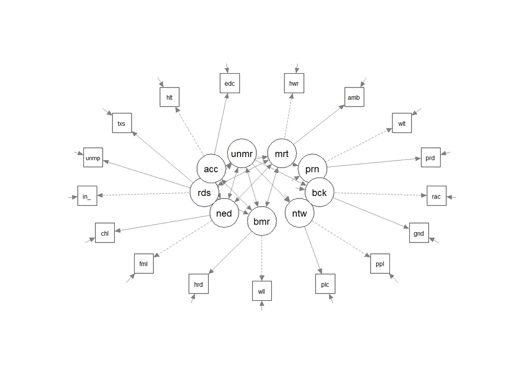

```r
  semPlot::semPaths(fit_mer_red2,layout = "circle", rotation = 3,
                intercepts = FALSE, style = "lisrel", curvePivot = TRUE,
                sizeMan = 4, sizeLat = 6)
```

## 2.4 Correlation factor scores

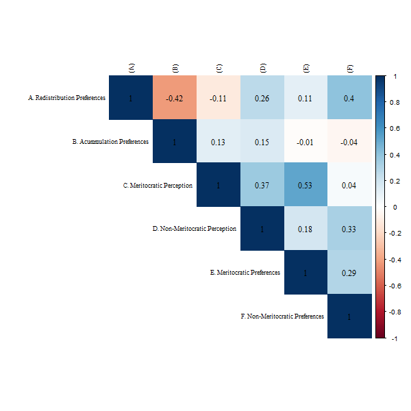

Correlation factor scores

```r
        # Factor scores
      fscores <- as.data.frame(lavPredict(fit_mer_red2))


        # Correlations
      cormat=cor(fscores[c(7,8,1,9,5,6)],
                 use="pairwise.complete.obs")


      #save
    png("output/results/corplot_totscores.png",width=600,height=600)


windowsFonts(A = windowsFont("Times New Roman"))
rownames(cormat) <-c(
    "A. Redistribution Preferences",
    "B. Acummulation Preferences",
    "C. Meritocratic Perception",
    "D. Non-Meritocratic Perception",
    "E. Meritocratic Preferences",
    "F. Non-Meritocratic Preferences")
colnames(cormat) <-c("(A)", "(B)","(C)","(D)","(E)","(F)")


    corrplot(
cormat,
  method = "color",
  type = "upper",
  tl.col = "black",
  addCoef.col = "black",
  diag = TRUE,
  family = "A",
  number.font = 6,
  tl.cex =0.75,
  number.cex = 1)

        dev.off()
```

# 3 Macro Bivariados.

## 3.1 Macro level corr

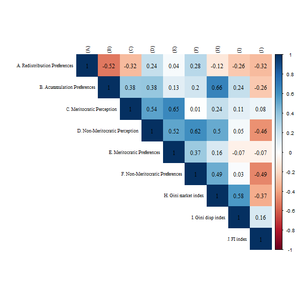

Macro level cor

```r
#Se agrega la base de datos dejando paises como
  mer_pref_agg=aggregate(mer_pref, by=list(mer_pref$v5c),
        FUN=mean, na.rm=TRUE)
      names(mer_pref_agg)[names(mer_pref_agg)=="Group.1"]="v5c"



load("input/data/proc/meritocracy.rda")


  # Adjust data
    merit_agg=aggregate(meritocracy, by=list(meritocracy$v5c),
        FUN=mean, na.rm=TRUE)
    names(merit_agg)[names(merit_agg)=="Group.1"]="v5c"
 #   names(merit_agg)
  #  dim(merit_agg)

load("input/data/proc/mer_pref_polycor.rda")



corMat <- cor(mer_pref_polycor, use="pairwise.complete.obs")

png("output/results/macrocor.png",width=600,height=600)


windowsFonts(A = windowsFont("Times New Roman"))
rownames(corMat) <-c(
    "A. Redistribution Preferences",
    "B. Acummulation Preferences",
    "C. Meritocratic Perception",
    "D. Non-Meritocratic Perception",
    "E. Meritocratic Preferences",
    "F. Non-Meritocratic Preferences",
    "H. Gini market index",
    "I. Gini disp index",
    "J. FI index")
colnames(corMat) <-c("(A)", "(B)","(C)","(D)","(E)","(F)","(H)","(I)","(J)")


    corrplot(
corMat,
  method = "color",
  type = "upper",
  tl.col = "black",
  addCoef.col = "black",
  diag = TRUE,
  family = "A",
  number.font = 6,
  tl.cex =0.75,
  number.cex = 1)

    dev.off()
```

## 3.2 Preferencias redistributivas.

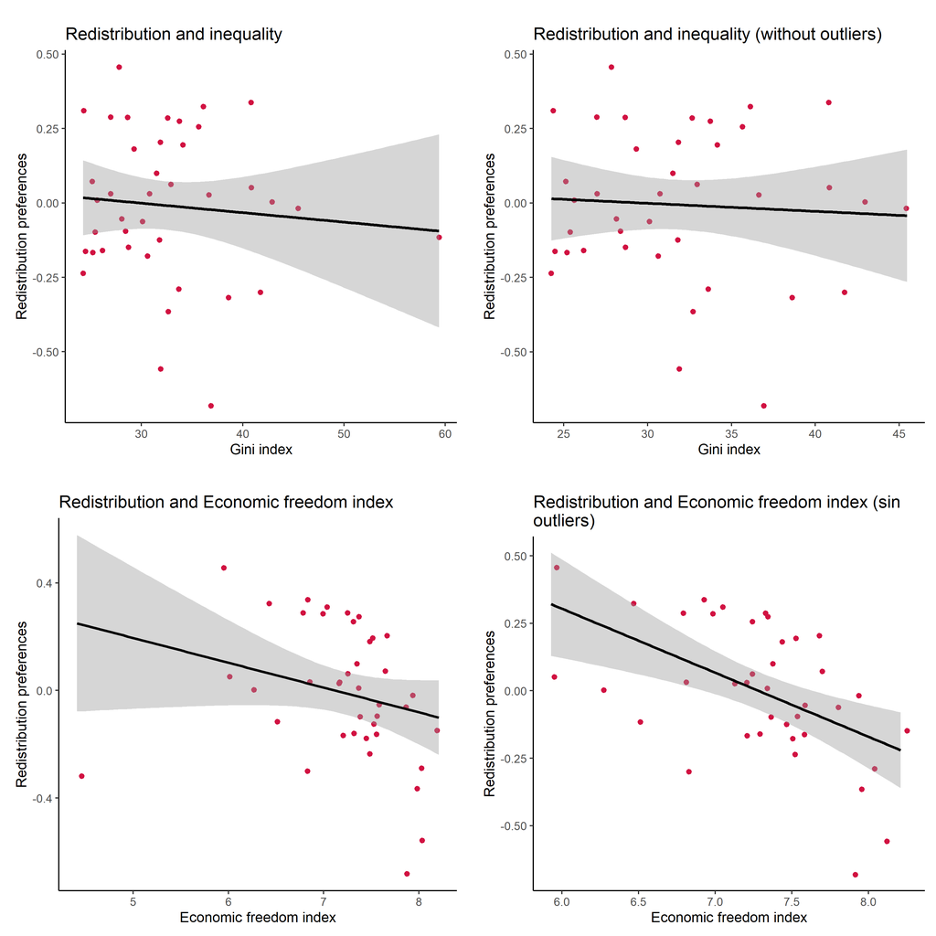

Redistribution preferences, gini and fi index

```r
plotredistgini<-plot_scatter(mer_pref_agg, gini_neto, redist,
    title = "Redistribution and inequality",
        #dot.labels = merit_agg$v5c,
        fit.line = "lm",
        show.ci = TRUE) + theme_classic()  + ylab("Redistribution preferences") + xlab("Gini index")

mer_pref_agg_zaf <- mer_pref_agg[which(mer_pref_agg$v5c!='ZAF'), ]

plotredistgini_outliers <- plot_scatter(mer_pref_agg_zaf, gini_neto, redist,
            title = "Redistribution and inequality (without outliers)",
         fit.line = lm,
            show.ci = TRUE
            ) + theme_classic() + ylab("Redistribution preferences") + xlab("Gini index")

plotredistfi<-plot_scatter(mer_pref_agg,  fi_index, redist,
    title = "Redistribution and Economic freedom index",
        #dot.labels = merit_agg$v5c,
        fit.line = "lm",
        show.ci = TRUE) + theme_classic() + ylab("Redistribution preferences") + xlab("Economic freedom index")

mer_pref_agg_ven <- mer_pref_agg[which(mer_pref_agg$v5c!='VEN'), ]

plotredistfi_outliers<-plot_scatter(mer_pref_agg_ven,  fi_index, redist,
    title = "Redistribution and Economic freedom index (sin outliers)",
        #dot.labels = merit_agg$v5c,
        fit.line = "lm",
        show.ci = TRUE) + theme_classic() + ylab("Redistribution preferences") + xlab("Economic freedom index")



ggsave(plot = plot_grid(list(plotredistgini, plotredistgini_outliers, plotredistfi, plotredistfi_outliers),margin = c(0.3,0.3,0.3,0.3), tags = c(" ", " ", " ", " ", " ", " ")), filename = "output/results/plot_redistmacro.png", width = 10, height = 10, dpi= "retina")
```

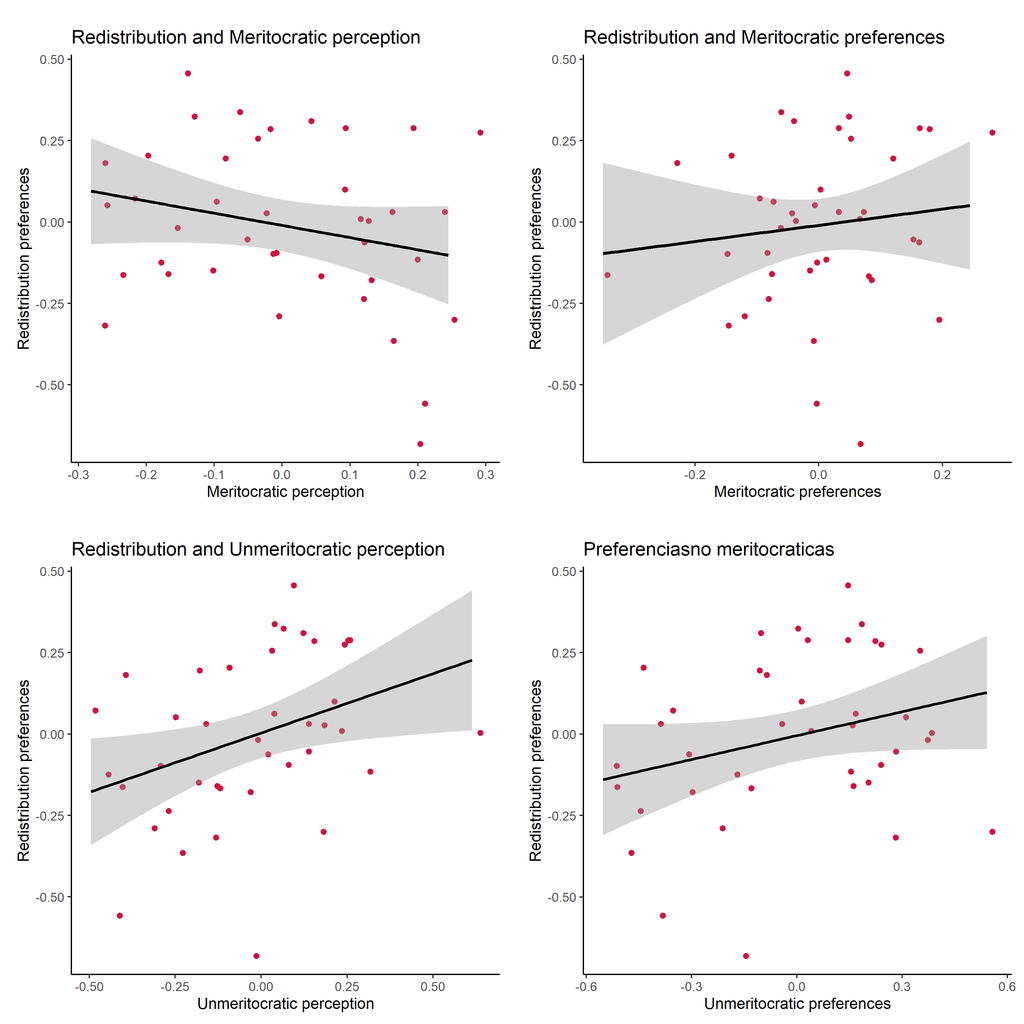

Redistribution preferences and Meritocratic beliefs

```r
plotredistmerit <- plot_scatter(mer_pref_agg,  merit, redist,
    title = "Redistribution and Meritocratic perception",
    #   dot.labels = merit_agg$v5c,
        fit.line = "lm",
        show.ci = TRUE)  + theme_classic() + ylab("Redistribution preferences") + xlab("Meritocratic perception")

plotredistbmerit <-plot_scatter(mer_pref_agg,  bmerit, redist,
    title = "Redistribution and Meritocratic preferences",
    #   dot.labels = merit_agg$v5c,
        fit.line = "lm",
        show.ci = TRUE)  + theme_classic() + ylab("Redistribution preferences") + xlab("Meritocratic preferences")

plotredistunmerit <-plot_scatter(mer_pref_agg,  unmerit, redist,
    title = "Redistribution and Unmeritocratic perception",
        #dot.labels = merit_agg$v5c,
        fit.line = "lm",
        show.ci = TRUE)  + theme_classic() + ylab("Redistribution preferences") + xlab("Unmeritocratic perception")


plotredistneed <-plot_scatter(mer_pref_agg,  need, redist,
    title = "Preferenciasno meritocraticas ",
        #dot.labels = merit_agg$v5c,
        fit.line = "lm",
        show.ci = TRUE)  + theme_classic() + ylab("Redistribution preferences") + xlab("Unmeritocratic preferences")



ggsave(plot = plot_grid(list(plotredistmerit, plotredistbmerit, plotredistunmerit, plotredistneed),margin = c(0.3,0.3,0.3,0.3), tags = c(" ", " ", " ", " ", " ", " ")), filename = "output/results/plot_redistmerit.png", width = 10, height = 10, dpi= "retina")
```

## 3.3 Preferencias de Mercantilizacion.

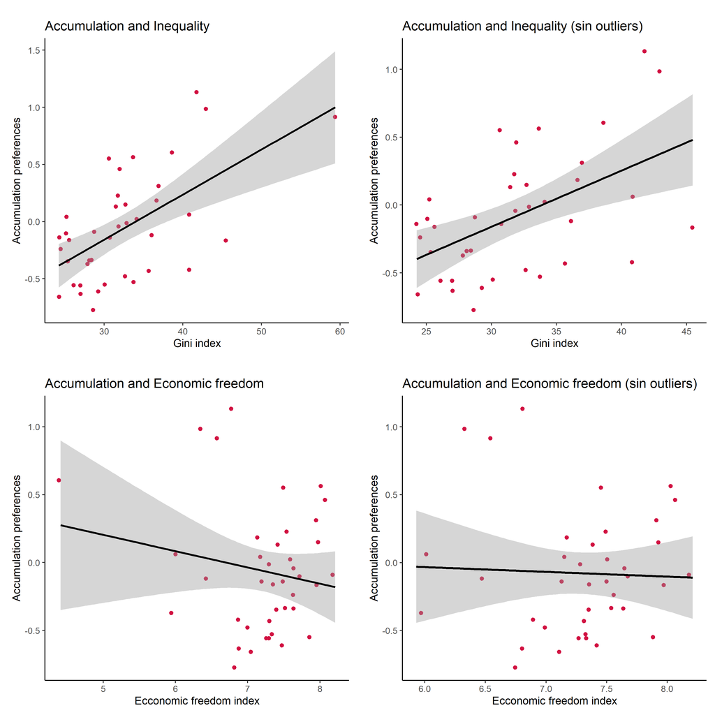

Accumulation preferences, gini and fi index

```r
plotaccumgini<-plot_scatter(mer_pref_agg, gini_neto, accum,
      title = "Accumulation and Inequality ",
        #dot.labels = merit_agg$v5c,
        fit.line = "lm",
        show.ci = TRUE)  + theme_classic() + ylab("Accumulation preferences") + xlab("Gini index")

mer_pref_agg_zaf <- mer_pref_agg[which(mer_pref_agg$v5c!='ZAF'), ]

plotaccumgini_outliers <- plot_scatter(mer_pref_agg_zaf, gini_neto, accum,
            title = "Accumulation and Inequality (sin outliers)",
         #dot.labels = merit_agg$v5c,
            fit.line = lm,
            show.ci = TRUE
            )  + theme_classic() + ylab("Accumulation preferences") + xlab("Gini index")


mer_pref_agg_ven <- mer_pref_agg[which(mer_pref_agg$v5c!='VEN'), ]

plotaccumfi<-plot_scatter(mer_pref_agg, fi_index, accum,
    title = "Accumulation and Economic freedom",
        #dot.labels = mer_pref_agg$v5c,
        fit.line = "lm",
        show.ci = TRUE)   + theme_classic() + ylab("Accumulation preferences") + xlab("Ecconomic freedom index")

plotaccumfi_outliers<-plot_scatter(mer_pref_agg_ven,  fi_index, accum,
    title = "Accumulation and Economic freedom (sin outliers)",
        #dot.labels = merit_agg$v5c,
        fit.line = "lm",
        show.ci = TRUE)   + theme_classic() + ylab("Accumulation preferences") + xlab("Ecconomic freedom index")



ggsave(plot = plot_grid(list(plotaccumgini, plotaccumgini_outliers, plotaccumfi, plotaccumfi_outliers),margin = c(0.3,0.3,0.3,0.3), tags = c(" ", " ", " ", " ", " ", " ")), filename = "output/results/plot_accumginifi.png", width = 10, height = 10, dpi= "retina")
```

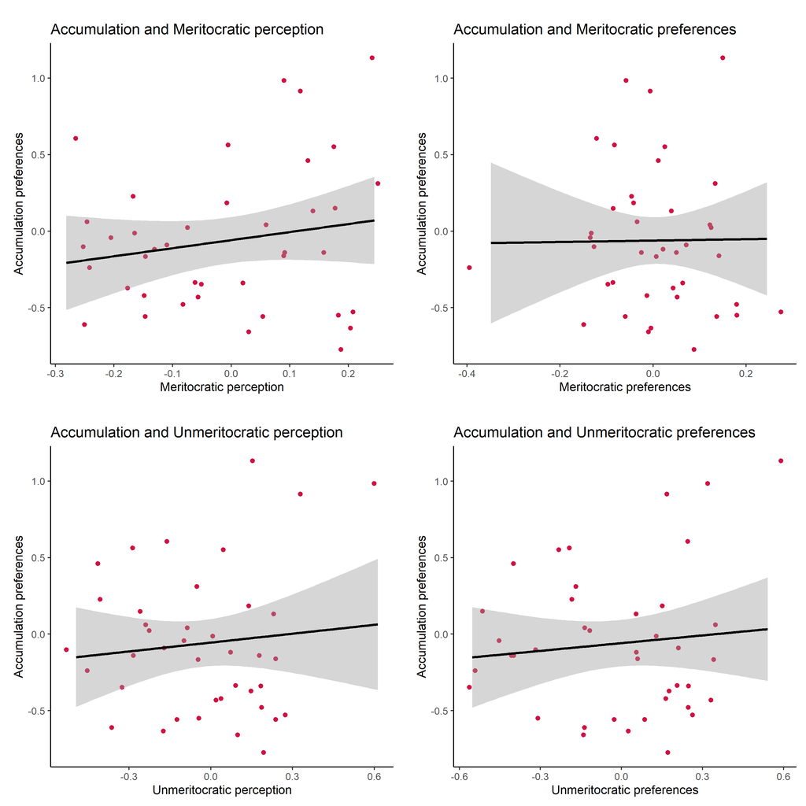

Accumulation preferences and Meritocratic beliefs

```r
plotaccummerit <- plot_scatter(mer_pref_agg,  merit, accum,
    title = "Accumulation and Meritocratic perception",
    #   dot.labels = merit_agg$v5c,
        fit.line = "lm",
        show.ci = TRUE) + theme_classic() + ylab("Accumulation preferences") + xlab("Meritocratic perception")

plotaccumbmerit <-plot_scatter(mer_pref_agg,  bmerit, accum,
    title = "Accumulation and Meritocratic preferences",
    #   dot.labels = merit_agg$v5c,
        fit.line = "lm",
        show.ci = TRUE) + theme_classic() + ylab("Accumulation preferences") + xlab("Meritocratic preferences")

plotaccumunmerit <-plot_scatter(mer_pref_agg,  unmerit, accum,
    title = "Accumulation and Unmeritocratic perception",
        #dot.labels = merit_agg$v5c,
        fit.line = "lm",
        show.ci = TRUE) + theme_classic() + ylab("Accumulation preferences") + xlab("Unmeritocratic perception")

plotaccumneed <-plot_scatter(mer_pref_agg,  need, accum,
    title = "Accumulation and Unmeritocratic preferences",
        #dot.labels = merit_agg$v5c,
        fit.line = "lm",
        show.ci = TRUE) + theme_classic() + ylab("Accumulation preferences") + xlab("Unmeritocratic preferences")




ggsave(plot = plot_grid(list(plotaccummerit, plotaccumbmerit, plotaccumunmerit, plotaccumneed),margin = c(0.3,0.3,0.3,0.3), tags = c(" ", " ", " ", " ", " ", " ")), filename = "output/results/plot_accummerit.png", width = 10, height = 10, dpi= "retina")
```

## 3.4 Creencias meritocraticas.

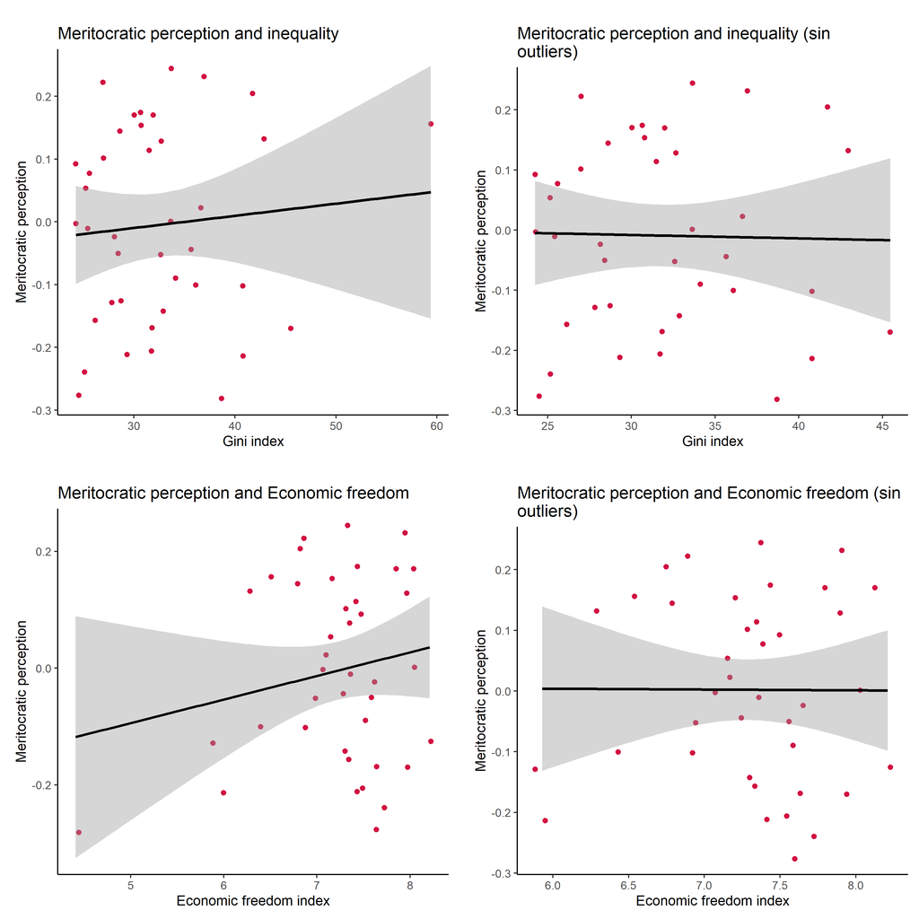

Meritocratic perception, gini and fi index

```r
plotginimerit <- plot_scatter(mer_pref_agg,gini_neto,  merit,
    title = "Meritocratic perception and inequality",
    #dot.labels = merit_agg$v5c,
        fit.line = "lm",
        show.ci = TRUE)  + theme_classic() + ylab("Meritocratic perception") + xlab("Gini index")


mer_pref_agg_zaf <- mer_pref_agg[which(mer_pref_agg$v5c!='ZAF'), ]

plotginimerit_out <- plot_scatter(mer_pref_agg_zaf,gini_neto,  merit,
    title = "Meritocratic perception and inequality (sin outliers)",
        #dot.labels = merit_agg$v5c,
        fit.line = "lm",
        show.ci = TRUE)  + theme_classic() + ylab("Meritocratic perception") + xlab("Gini index")

plotgfimerit <- plot_scatter(mer_pref_agg,fi_index,  merit,
    title = "Meritocratic perception and Economic freedom",
    #dot.labels = mer_pref_agg$v5c,
        fit.line = "lm",
        show.ci = TRUE)  + theme_classic() + ylab("Meritocratic perception") + xlab("Economic freedom index")


mer_pref_agg_ven <- mer_pref_agg[which(mer_pref_agg$v5c!='VEN'), ]

plotgfimerit_out<- plot_scatter(mer_pref_agg_ven,fi_index,  merit,
    title = "Meritocratic perception and Economic freedom (sin outliers)",
    #   dot.labels = mer_pref_agg_ven$v5c,
        fit.line = "lm",
        show.ci = TRUE)  + theme_classic() + ylab("Meritocratic perception") + xlab("Economic freedom index")


ggsave(plot = plot_grid(list(plotginimerit, plotginimerit_out, plotgfimerit, plotgfimerit_out),margin = c(0.3,0.3,0.3,0.3), tags = c(" ", " ", " ", " ", " ", " ")), filename = "output/results/plot_meritginifi.png", width = 10, height = 10, dpi= "retina")
```

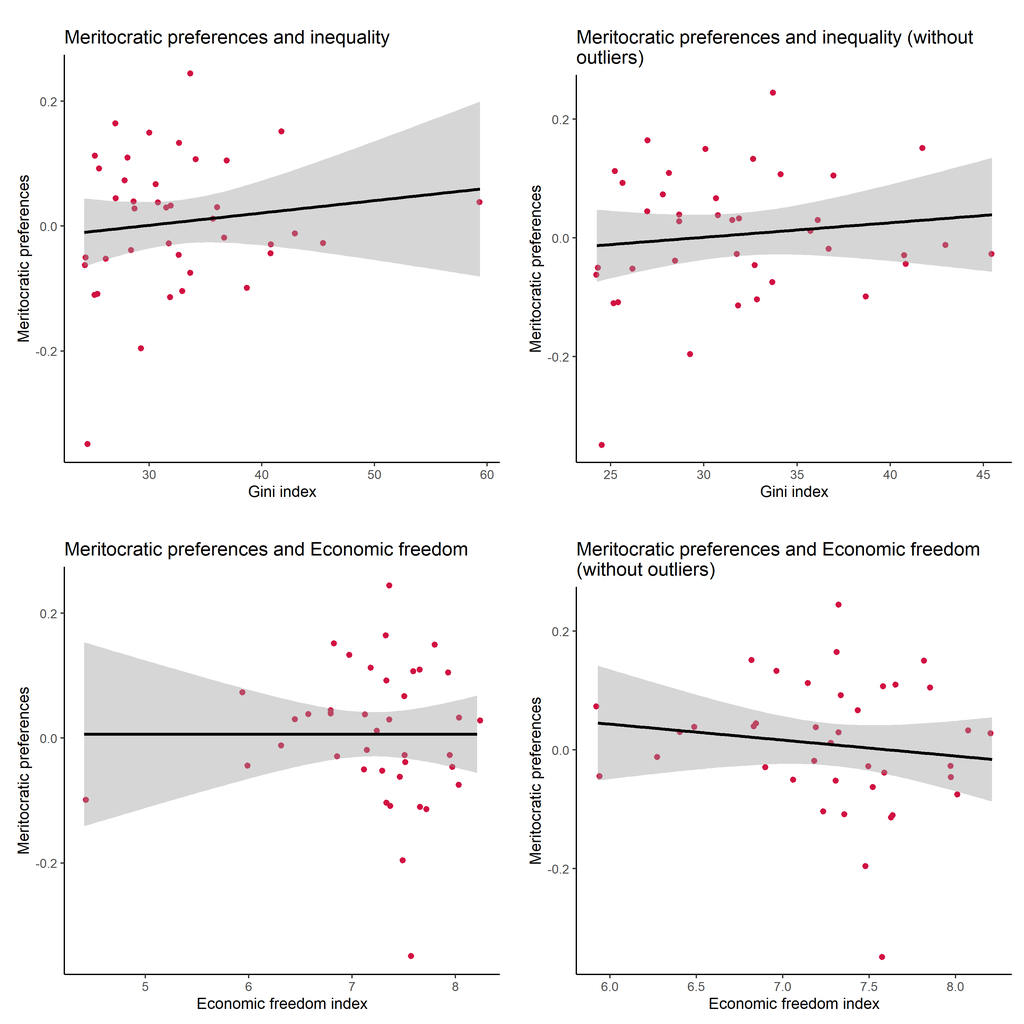

Meritocratic preferences, gini and fi index

```r
plotginibmerit <- plot_scatter(mer_pref_agg,gini_neto,  bmerit,
    title = "Meritocratic preferences and inequality",
    #dot.labels = mer_pref_agg$v5c,
        fit.line = "lm",
        show.ci = TRUE) + theme_classic() + ylab("Meritocratic preferences") + xlab("Gini index")


mer_pref_agg_zaf <- mer_pref_agg[which(mer_pref_agg$v5c!='ZAF'), ]

plotginibmerit_out<- plot_scatter(mer_pref_agg_zaf,gini_neto,  bmerit,
    title = "Meritocratic preferences and inequality (without outliers)",
    #   dot.labels = mer_pref_agg$v5c,
        fit.line = "lm",
        show.ci = TRUE) + theme_classic()  + ylab("Meritocratic preferences") + xlab("Gini index")

plotfibmerit <- plot_scatter(mer_pref_agg,fi_index,  bmerit,
    title = "Meritocratic preferences and Economic freedom",
    #dot.labels = mer_pref_agg$v5c,
        fit.line = "lm",
        show.ci = TRUE) + theme_classic() + ylab("Meritocratic preferences") + xlab("Economic freedom index")


mer_pref_agg_ven <- mer_pref_agg[which(mer_pref_agg$v5c!='VEN'), ]

plotfibmerit_out <- plot_scatter(mer_pref_agg_ven,fi_index,  bmerit,
    title = "Meritocratic preferences and Economic freedom (without outliers)",
    #   dot.labels = mer_pref_agg_ven$v5c,
        fit.line = "lm",
        show.ci = TRUE) + theme_classic() + ylab("Meritocratic preferences") + xlab("Economic freedom index")




ggsave(plot = plot_grid(list(plotginibmerit, plotginibmerit_out, plotfibmerit, plotfibmerit_out),margin = c(0.3,0.3,0.3,0.3), tags = c(" ", " ", " ", " ", " ", " ")), filename = "output/results/plot_bmeritginifi.png", width = 10, height = 10, dpi= "retina")
```

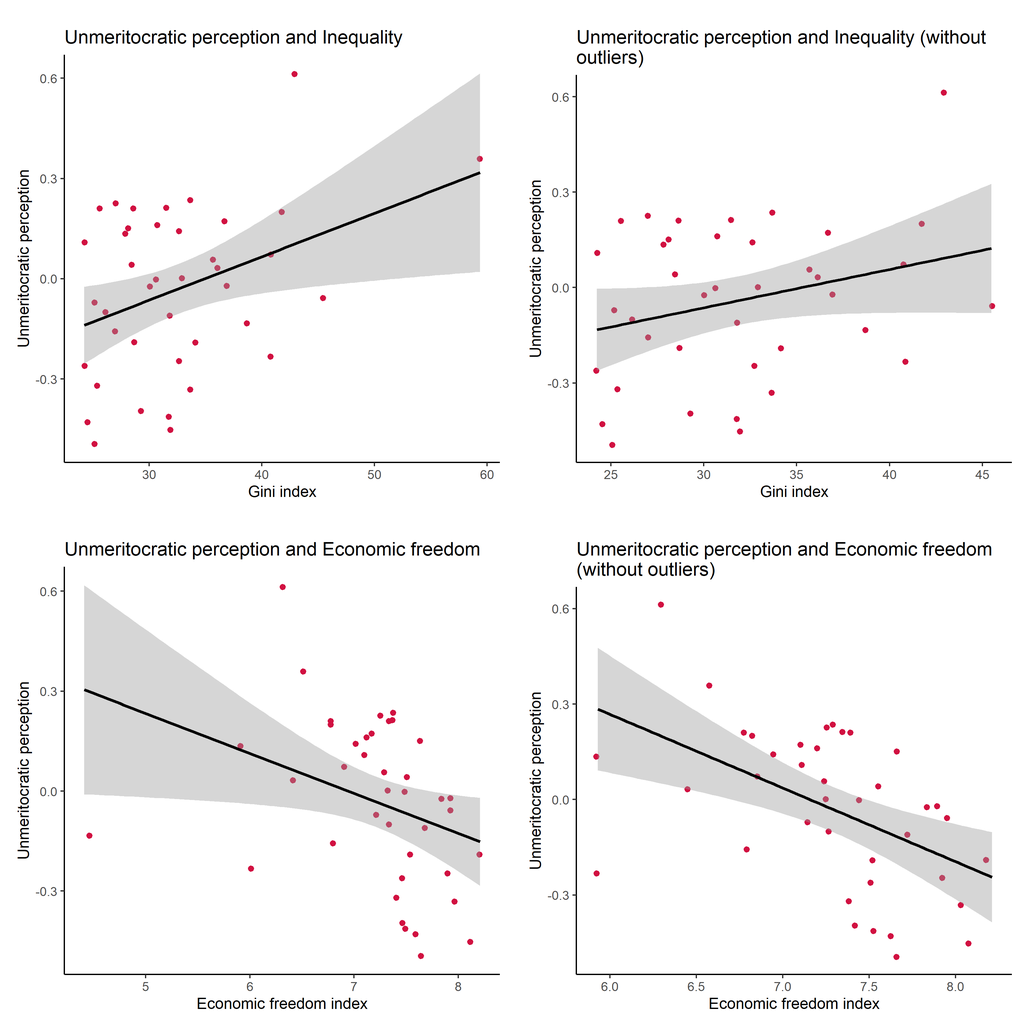

Non Meritocratic perception, gini and fi index

```r
plotginiunmerit <- plot_scatter(mer_pref_agg,gini_neto,  unmerit,
      title = "Unmeritocratic perception and Inequality",
    #dot.labels = mer_pref_agg$v5c,
        fit.line = "lm",
        show.ci = TRUE) + theme_classic() + ylab("Unmeritocratic perception") +xlab("Gini index")


mer_pref_agg_zaf <- mer_pref_agg[which(mer_pref_agg$v5c!='ZAF'), ]

plotginiunmerit_out<- plot_scatter(mer_pref_agg_zaf,gini_neto,  unmerit,
    title = "Unmeritocratic perception and Inequality (without outliers)",
    #   dot.labels = mer_pref_agg$v5c,
        fit.line = "lm",
        show.ci = TRUE)  + theme_classic() + ylab("Unmeritocratic perception") +xlab("Gini index")

plotfiunmerit <- plot_scatter(mer_pref_agg,fi_index,  unmerit,
    title = "Unmeritocratic perception and Economic freedom",
    #dot.labels = mer_pref_agg$v5c,
        fit.line = "lm",
        show.ci = TRUE)  + theme_classic() + ylab("Unmeritocratic perception") + xlab("Economic freedom index")


mer_pref_agg_ven <- mer_pref_agg[which(mer_pref_agg$v5c!='VEN'), ]

plotfiunmerit_out <- plot_scatter(mer_pref_agg_ven,fi_index,  unmerit,
    title = "Unmeritocratic perception and Economic freedom (without outliers)",
    #   dot.labels = mer_pref_agg_ven$v5c,
        fit.line = "lm",
        show.ci = TRUE)  + theme_classic() + ylab("Unmeritocratic perception") + xlab("Economic freedom index")




ggsave(plot = plot_grid(list(plotginiunmerit, plotginiunmerit_out, plotfiunmerit, plotfiunmerit_out),margin = c(0.3,0.3,0.3,0.3), tags = c(" ", " ", " ", " ", " ", " ")), filename = "output/results/plot_unmeritginifi.png", width = 10, height = 10, dpi= "retina")
```

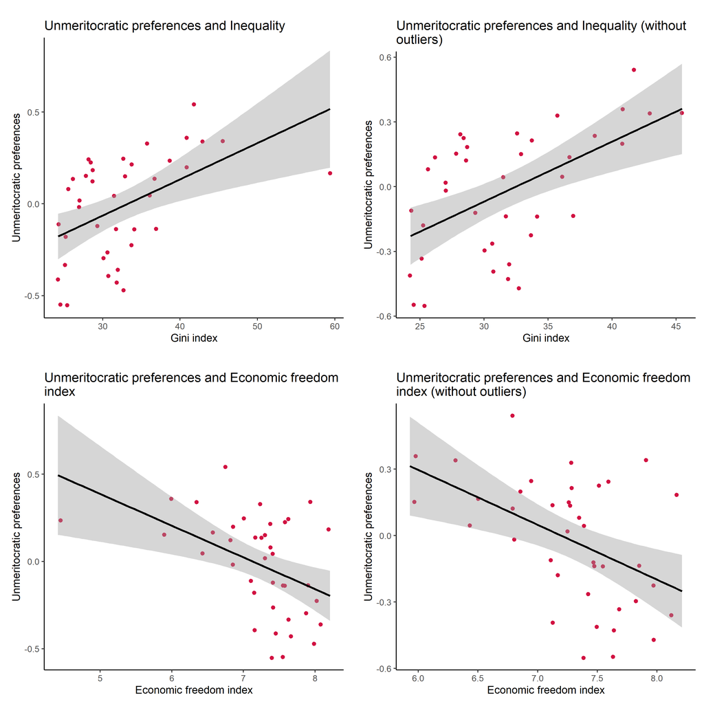

Non Meritocratic preferences, gini and fi index

```r
plotginineed <- plot_scatter(mer_pref_agg,gini_neto,  need,
    title = "Unmeritocratic preferences and Inequality",
    #dot.labels = mer_pref_agg$v5c,
        fit.line = "lm",
        show.ci = TRUE) + theme_classic() + ylab("Unmeritocratic preferences") + xlab("Gini index")


mer_pref_agg_zaf <- mer_pref_agg[which(mer_pref_agg$v5c!='ZAF'), ]

plotginineed_out<- plot_scatter(mer_pref_agg_zaf,gini_neto,  need,
    title = "Unmeritocratic preferences and Inequality (without outliers)",
    #   dot.labels = mer_pref_agg$v5c,
        fit.line = "lm",
        show.ci = TRUE)  + theme_classic() + ylab("Unmeritocratic preferences") + xlab("Gini index")

plotfineed <- plot_scatter(mer_pref_agg,fi_index,  need,
    title = "Unmeritocratic preferences and Economic freedom index ",
    #dot.labels = mer_pref_agg$v5c,
        fit.line = "lm",
        show.ci = TRUE)  + theme_classic() + ylab("Unmeritocratic preferences") + xlab("Economic freedom index")


mer_pref_agg_ven <- mer_pref_agg[which(mer_pref_agg$v5c!='VEN'), ]

plotfineed_out <- plot_scatter(mer_pref_agg_ven,fi_index,  need,
    title = "Unmeritocratic preferences and Economic freedom index (without outliers)",
    #   dot.labels = mer_pref_agg_ven$v5c,
        fit.line = "lm",
        show.ci = TRUE)  + theme_classic() + ylab("Unmeritocratic preferences") + xlab("Economic freedom index")



ggsave(plot = plot_grid(list(plotginineed, plotginineed_out, plotfineed, plotfineed_out),margin = c(0.3,0.3,0.3,0.3), tags = c(" ", " ", " ", " ", " ", " ")), filename = "output/results/plot_needginifi.png", width = 10, height = 10, dpi= "retina")
```

# 4 Modelos Multivariable Multinivel

## 4.1 Modelos nulos: correlacion intraclase.

```r
load(file="input/data/proc/mer_pref.rda")
# Modelo nulo
results_0_redist  = lmer(redist ~ 1 + (1| v5c), data = mer_pref, REML=F)

results_0_accum = lmer(accum ~ 1 + (1| v5c), data = mer_pref, REML=F)


htmlreg(list(results_0_redist,results_0_accum), caption = "null model of redistribution preferences and accumulation preferences", custom.model.names = c("Redistribution", "Accumulation"), caption.adove = T, star.symbol = "\\*")
```

null model of redistribution preferences and accumulation preferences

|  | Redistribution | Accumulation |
| --- | --- | --- |
| (Intercept) | -0.01 | -0.06 |
|  | (0.04) | (0.07) |
| AIC | 98698.04 | 154799.67 |
| BIC | 98724.78 | 154826.41 |
| Log Likelihood | -49346.02 | -77396.83 |
| Num. obs. | 55021 | 55021 |
| Num. groups: v5c | 40 | 40 |
| Var: v5c (Intercept) | 0.06 | 0.22 |
| Var: Residual | 0.35 | 0.97 |

***p < 0.001; **p < 0.01; *p < 0.05

```r
#reghelper::ICC(results_0_redist)
```

```r
# Modelo nulo

# Correlacion intraclases accum


df<-data.frame(Variance=c("Between","Whithin"),
               porcentaje=c(15,85))
ggplot(df,aes(x="",y=porcentaje, fill=Variance))+
  geom_bar(stat = "identity",color="white")+
  coord_polar(theta="y") +
     geom_text(aes(label=paste(porcentaje, "%")),
              position=position_stack(vjust=0.5),color="white",size=6)+
  coord_polar(theta = "y") + ggtitle("Correlacion intraclase prederencias redistributivas")


reghelper::ICC(results_0_accum)
```

```
## [1] 0.1814155
```

[figure not shown]

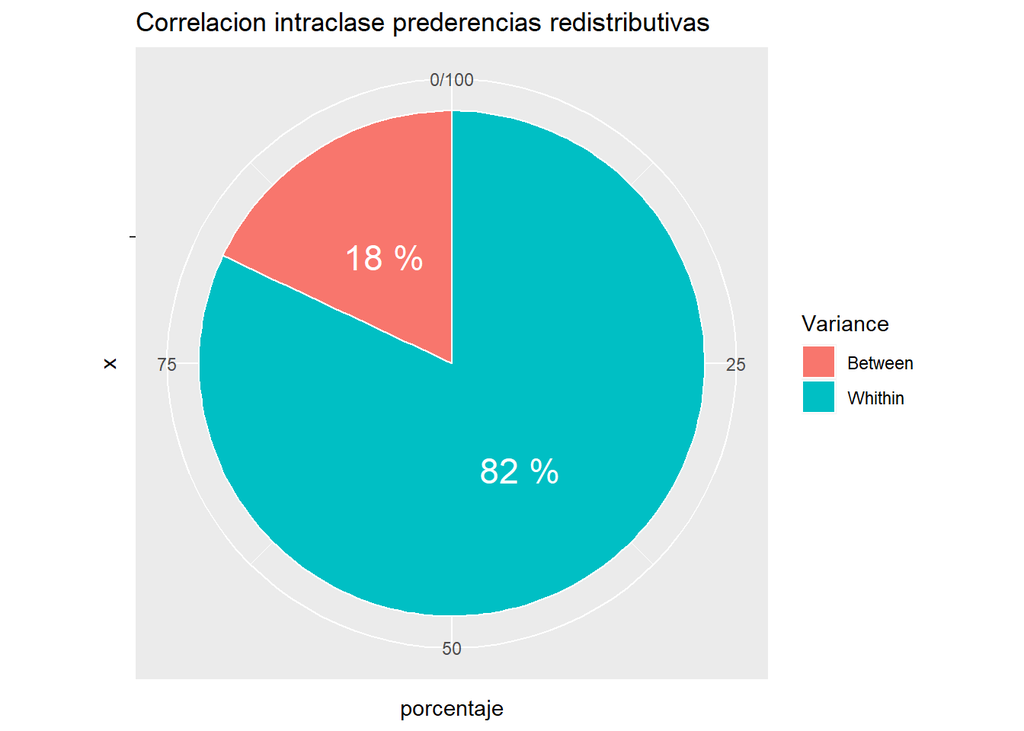

Correlacion intraclase

```r
df<-data.frame(Variance=c("Between","Whithin"),
               porcentaje=c(18,82))
ggplot(df,aes(x="",y=porcentaje, fill=Variance))+
  geom_bar(stat = "identity",color="white")+
  coord_polar(theta="y") +
     geom_text(aes(label=paste(porcentaje, "%")),
              position=position_stack(vjust=0.5),color="white",size=6)+
  coord_polar(theta = "y") + ggtitle("Correlacion intraclase prederencias redistributivas")
```

> Aproximadamente un 15% de la varianza de las preferencias redistributivas se encuentra entre paises

## 4.2 Modelos de Preferencias redistributivas.

```r
results_1_redist__1  = lmer(redist ~  gini_neto + fi_index + 1 + (1| v5c), data = mer_pref, REML=F)

results_1_redist_3 = lmer(redist ~ merit + 1 +  (1| v5c), data = mer_pref, REML=F)

results_1_redist_4 = lmer(redist ~  merit + bmerit + 1 +  (1| v5c), data = mer_pref, REML=F)

results_1_redist_5 = lmer(redist ~  merit + bmerit + unmerit + 1 +  (1| v5c), data = mer_pref, REML=F)

results_1_redist_6 = lmer(redist ~ merit + bmerit + unmerit + need + 1 +  (1| v5c), data = mer_pref, REML=F)

results_1_redist_7 = lmer(redist ~ gini_neto + fi_index + merit + bmerit + unmerit + need + 1 +  (1| v5c), data = mer_pref, REML=F)

results_1_redist_9 = lmer(redist ~ gini_neto + fi_index + merit + bmerit + unmerit + need + sstatus + as.factor(movstatus) + univ + as.factor(quintile_miss)  + sex + age  + 1 +  (1| v5c), data = mer_pref, REML=F)


results_2_redist_macro_bv = lmer(redist ~ univ + as.factor(quintile_miss) + sstatus + as.factor(movstatus) + sex + age  + merit + bmerit + unmerit + need + gini_neto + fi_index + 1 +  (1 + merit| v5c), data= mer_pref, REML=F)

results_3_redist_macro_bvi = lmer(redist ~ univ + as.factor(quintile_miss) +    sstatus + as.factor(movstatus) + sex + age  + merit + bmerit + unmerit + need + merit*gini_neto + fi_index + 1 +  (1 + merit| v5c), data = mer_pref, REML=F)



htmlreg(list(results_1_redist__1, results_1_redist_3,results_1_redist_4,results_1_redist_5,results_1_redist_6,results_1_redist_7, results_1_redist_9, results_2_redist_macro_bv, results_3_redist_macro_bvi),caption = "Redistribution preference models", omit.coef = "(sstatus)|(movstatus)|(univ)|(quintile_miss)|(age)|(sex)", custom.coef.names = c("Intercept", "Gini index", "Economic freedom index", "Meritocratic perception", "Meritocratic preference", "Unmeritocratic Perception","Unmerit preference", "GINI x Merit-perception"), caption.above = T, star.symbol = "\\*", center = T, custom.note = "$***p <$ 0.001, $**p <$ 0.01, $*p <$ 0.05 <br> Since Model 6 control by subjetive status, mov subjetive status, Ed.univ, quintile_miss, age and sex")
```

Redistribution preference models

|  | Model 1 | Model 2 | Model 3 | Model 4 | Model 5 | Model 6 | Model 7 | Model 8 | Model 9 |
| --- | --- | --- | --- | --- | --- | --- | --- | --- | --- |
| Intercept | 1.04* | -0.01 | -0.01 | -0.01 | -0.00 | 0.93* | 0.95* | 1.18** | 0.87* |
|  | (0.50) | (0.04) | (0.04) | (0.04) | (0.04) | (0.47) | (0.48) | (0.38) | (0.39) |
| Gini index | -0.01 |  |  |  |  | -0.01 | -0.01 | -0.02*** | -0.01 |
|  | (0.01) |  |  |  |  | (0.01) | (0.01) | (0.00) | (0.01) |
| Economic freedom index | -0.11* |  |  |  |  | -0.09 | -0.09 | -0.08 | -0.08 |
|  | (0.06) |  |  |  |  | (0.05) | (0.05) | (0.04) | (0.04) |
| Meritocratic perception |  | -0.00 | -0.07*** | -0.13*** | -0.06*** | -0.06*** | -0.05*** | -0.06** | -0.32*** |
|  |  | (0.01) | (0.01) | (0.01) | (0.01) | (0.01) | (0.01) | (0.02) | (0.09) |
| Meritocratic preference |  |  | 0.11*** | 0.12*** | 0.03*** | 0.03*** | 0.03*** | 0.04*** | 0.04*** |
|  |  |  | (0.01) | (0.01) | (0.01) | (0.01) | (0.01) | (0.01) | (0.01) |
| Unmeritocratic Perception |  |  |  | 0.13*** | 0.06*** | 0.06*** | 0.07*** | 0.06*** | 0.06*** |
|  |  |  |  | (0.00) | (0.01) | (0.01) | (0.01) | (0.01) | (0.01) |
| Unmerit preference |  |  |  |  | 0.16*** | 0.16*** | 0.14*** | 0.14*** | 0.14*** |
|  |  |  |  |  | (0.00) | (0.00) | (0.00) | (0.00) | (0.00) |
| GINI x Merit-perception |  |  |  |  |  |  |  |  | 0.01** |
|  |  |  |  |  |  |  |  |  | (0.00) |
| AIC | 98697.83 | 98699.77 | 98398.92 | 97750.86 | 95971.09 | 95970.77 | 91023.76 | 90606.54 | 90600.09 |
| BIC | 98742.41 | 98735.43 | 98443.50 | 97804.35 | 96033.50 | 96051.01 | 91210.07 | 90810.60 | 90813.02 |
| Log Likelihood | -49343.91 | -49345.89 | -49194.46 | -48869.43 | -47978.55 | -47976.39 | -45490.88 | -45280.27 | -45276.04 |
| Num. obs. | 55021 | 55021 | 55021 | 55021 | 55021 | 55021 | 52681 | 52681 | 52681 |
| Num. groups: v5c | 40 | 40 | 40 | 40 | 40 | 40 | 40 | 40 | 40 |
| Var: v5c (Intercept) | 0.06 | 0.06 | 0.06 | 0.05 | 0.05 | 0.05 | 0.05 | 0.06 | 0.05 |
| Var: Residual | 0.35 | 0.35 | 0.35 | 0.34 | 0.33 | 0.33 | 0.33 | 0.32 | 0.32 |
| Var: v5c merit |  |  |  |  |  |  |  | 0.02 | 0.01 |
| Cov: v5c (Intercept) merit |  |  |  |  |  |  |  | 0.02 | 0.02 |

> **Variables macroeconómicas**:solo la libertad económica posee el efecto negativo esperado sobre las preferencias redistributivas, según un criterio del 95% de confianza. No obstante, este efecto deja de ser significativo al ser controlado por las cuatro variables de creencias meritocraticas, lo cual sugiere la posibilidad de una mediación, en la cual un contexto de mayor libre mercado fomenta creencias meritocraticas que afectan negativamente las preferencias redistributivas.

> **Creencias meritocraticas**: la variable percepcion meritocratica no posee un efecto significativo sobre la variable preferencias redistributivas hasta ser controlada por las preferencias meritocraticas, las cuales tienen un efecto positivo sobre la preferencia por la redistribucion. Esto destaca la importancia de diferenciar en los modelos de medidas percepciones y preferencias pues pueden tener efectos contrarios sobre una misma variable, anulando la significación de dicho efecto. En términos sustantivos esto indica que lo importante es la percepcion de distribucion según talento y esfuerzo, separado de la creencia de que el mundo debería funcionar así. El efecto de esta variable vuelve a crecer cuando se controla por las percepciones no meritocraticas, pero disminuye considerablemente al incorporar la variable preferencia no meritocratica de pago según necesidades. Esta ultima variable, es aquella que mayor efecto posee sobre las preferencias redistributivas, lo cual nos sugiere que la preferencia por un estado que promueva la igualdad está relacionada con la consideracion de las necesidades de las personas a la hora de distribuir recursos.

> **Estatus subjetivo**: puede verse que ambas poseen un efecto significativo incluso según un criterio de 99,9% de confianza. El Efecto de la variable estatus subjetivo es negativo, es decir, una persona que se considera en una posición subjetiva alta posee una menor preferencia por al redistribucion. Por su parte, la movilidad subjetiva posee un efecto positivo sobre las preferencias redistributivas, cuando esta esta controladas por el estatus subjetivo individual y las creencias meritocraticas. Quizás, el contacto con grupos desfavorecidos puede generar mayor empatía.

> **Variables demográficas**: Estas variables son todas significativas. Además, su inclusión en el modelo multinivel no anula la significación de las variables sustantivas del modelo. Entre ellas destaca la variable quintil de ingreso, según la cual, pertenecer al quintil más rico, implica una menor preferencia por la redistribucion.

> Al *aleatorizar la pendientre* entre percepcion de meritocracia y preferencias redistributivas mejora significativamente el modelo, lo cual se debe a las diferencias entre paises en torno a dicha relacion. Comos se ejemplifica en el grafico de pendientes aleatorias, las relaciones incluso cambian de sentido de un pais a otro.

> Al incluir la *interaccion entre niveles* el modelo mejora signifiicativamente. En alguna medida, lo que hace variar la pendiente de la relacion, es la desigualdad del pais.

```r
results_1_redist_dem  = lmer(redist ~ univ + as.factor(quintile_miss) + sstatus + as.factor(movstatus) + sex + age + 1 + (1| v5c), data = mer_pref, REML=F)

results_1_redist_indsust = lmer(redist ~ univ + as.factor(quintile_miss) +  sstatus + as.factor(movstatus) + sex + age  + merit + bmerit + unmerit + need + 1 +  (1| v5c), data = mer_pref, REML=F)

results_1_redist_macro = lmer(redist ~ univ + as.factor(quintile_miss) +    sstatus + as.factor(movstatus) + sex + age  + merit + bmerit + unmerit + need + gini_neto + fi_index + 1 +  (1| v5c), data = mer_pref, REML=F)

results_2_redist_macro_bv = lmer(redist ~ univ + as.factor(quintile_miss) + sstatus + as.factor(movstatus) + sex + age  + merit + bmerit + unmerit + need + gini_neto + fi_index + 1 +  (1 + merit| v5c), data= mer_pref, REML=F)

results_3_redist_macro_bvi = lmer(redist ~ univ + as.factor(quintile_miss) +    sstatus + as.factor(movstatus) + sex + age  + merit + bmerit + unmerit + need + merit*gini_neto + fi_index + 1 +  (1 + merit| v5c), data = mer_pref, REML=F)


results_3_redist_macro_bvi_2 = lmer(redist ~ univ + as.factor(quintile_miss) +  sstatus + as.factor(movstatus) + sex + age  + merit + bmerit + unmerit + need + merit*fi_index + gini_neto + 1 +  (1 + merit| v5c), data = mer_pref, REML=F)

#htmlreg(list(results_1_redist_macro,results_2_redist_macro_bv, results_3_redist_macro_bvi,results_3_redist_macro_bvi_2), caption = "Pendiente aleatorea e interaccion entre niveles", omit.coef = "(sstatus)|(movstatus)|(univ)|(quintile_miss)|(age)|(sex)")
```

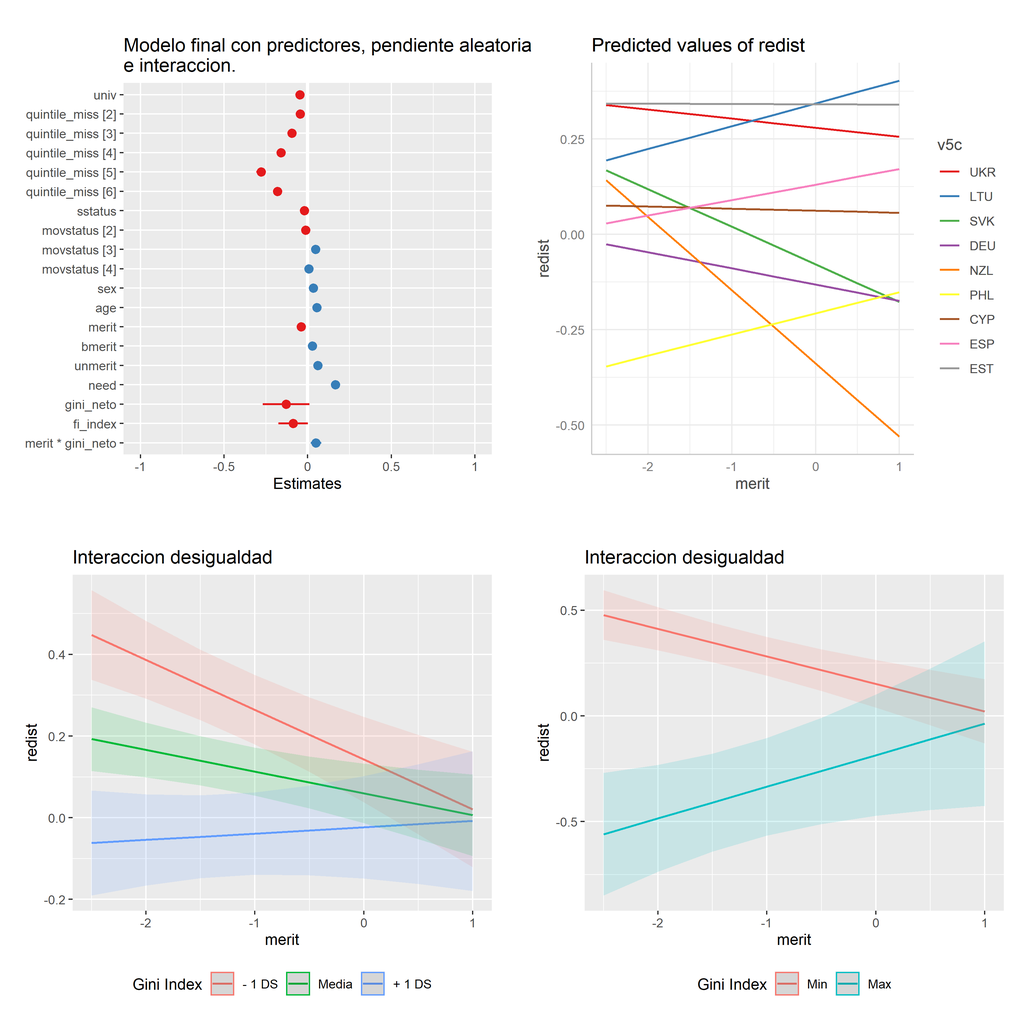

Modelos de Redistribucion; Efectos, pendientes aleatorias e interacciones

```r
results_3_redist_macro_bvi_efectplot <- sjPlot::plot_model(results_3_redist_macro_bvi, type="std", title = "Modelo final con predictores, pendiente aleatoria e interaccion.")

    ggsave(results_3_redist_macro_bvi_efectplot, filename = "output/results/results_3_redist_macro_bvi_efectplot.png", width = 10, height = 10, dpi= "retina")


graf2=ggpredict(results_2_redist_macro_bv, terms = c("merit","v5c [sample = 9]"), type="re")
pendiente_aleatoria_redistbv <- plot(graf2)

ggsave(pendiente_aleatoria_redistbv, filename = "output/results/pendiente_aleatoria_redistbv.png", width = 10, height = 10, dpi= "retina")


results_3_redist_macro_bvi_interacgini_meansd <- sjPlot::plot_model(results_3_redist_macro_bvi, type = c("int"), title = "Interaccion desigualdad",  mdrt.values = "meansd") +  scale_color_discrete("Gini Index", labels = c("- 1 DS", "Media", "+ 1 DS")) + theme(legend.position = "bottom")
results_3_redist_macro_bvi_interacgini_minmax <- sjPlot::plot_model(results_3_redist_macro_bvi, type = c("int"), title = "Interaccion desigualdad") +  scale_color_discrete("Gini Index", labels = c("Min", "Max")) + theme(legend.position = "bottom")



ggsave(plot_grid(list(results_3_redist_macro_bvi_efectplot, pendiente_aleatoria_redistbv,results_3_redist_macro_bvi_interacgini_meansd, results_3_redist_macro_bvi_interacgini_minmax) ,margin = c(0.5,0.5,0.5,0.5), tags = c(" ", " "," ", " ")), filename = "output/results/results_3_redist_macro_bvi_interacgini.png", width = 10, height = 10, dpi= "retina")


#sjPlot::plot_model(results_3_redist_macro_bvi_2, type = c("int"), title = "Interaccion libertad economica",  mdrt.values = "meansd")
```

```r
#analisis de casos influyentes
```

## 4.3 Modelos de Preferencias por marketizacion (accu).

```r
results_1_accum__1  = lmer(accum ~  gini_neto + fi_index + 1 + (1| v5c), data = mer_pref, REML=F)

results_1_accum__2  = lmer(accum ~  gini_neto + fi_index + 1 + (1| v5c), data = mer_pref, REML=F)

results_1_accum_3 = lmer(accum ~ merit + 1 +  (1| v5c), data = mer_pref, REML=F)

results_1_accum_4 = lmer(accum ~  merit + bmerit + 1 +  (1| v5c), data = mer_pref, REML=F)

results_1_accum_5 = lmer(accum ~  merit + bmerit + unmerit + 1 +  (1| v5c), data = mer_pref, REML=F)

results_1_accum_6 = lmer(accum ~ merit + bmerit + unmerit + need + 1 +  (1| v5c), data = mer_pref, REML=F)

results_1_accum_7 = lmer(accum ~ gini_neto + fi_index + merit + bmerit + unmerit + need + 1 +  (1| v5c), data = mer_pref, REML=F)

results_1_accum_8 = lmer(accum ~ gini_neto + fi_index + merit + bmerit + unmerit + need + sstatus + as.factor(movstatus) + 1 +  (1| v5c), data = mer_pref, REML=F)

results_1_accum_9 = lmer(accum ~ gini_neto + fi_index + merit + bmerit + unmerit + need + sstatus + as.factor(movstatus) + univ + as.factor(quintile_miss)  + sex + age  + 1 +  (1| v5c), data = mer_pref, REML=F)


results_1_accum_macro = lmer(accum ~ univ + as.factor(quintile_miss) +  sstatus + as.factor(movstatus) + sex + age  + merit + bmerit + unmerit + need + gini_neto + fi_index + 1 +  (1| v5c), data = mer_pref, REML=F)

results_2_accum_macro_bv = lmer(accum ~ univ + as.factor(quintile_miss) +   sstatus + as.factor(movstatus) + sex + age  + merit + bmerit + unmerit + need +  gini_neto + fi_index + 1 +  (1 + merit| v5c), data = mer_pref, REML=F)

results_3_accum_macro_bvi = lmer(accum ~ univ + as.factor(quintile_miss) +  sstatus + as.factor(movstatus) + sex + age  + merit + bmerit + unmerit + need +  gini_neto + merit*fi_index + 1 +  (1 + merit| v5c), data = mer_pref, REML=F)

results_3_accum_macro_bvi_2 = lmer(accum ~ univ + as.factor(quintile_miss) +    sstatus + as.factor(movstatus) + sex + age  + merit + bmerit + unmerit + need +  fi_index + merit*gini_neto + 1 +  (1 + merit| v5c), data = mer_pref, REML=F)

#htmlreg(list(results_1_accum_macro,results_2_accum_macro_bv,results_3_accum_macro_bvi, results_3_accum_macro_bvi_2), star.symbol = "\\*")



htmlreg(list(results_1_accum__1,results_1_accum__2, results_1_accum_3,results_1_accum_4,results_1_accum_5,results_1_accum_6,results_1_accum_7, results_2_accum_macro_bv, results_3_accum_macro_bvi), caption = "Accumulation preferences models", omit.coef = "(sstatus)|(movstatus)|(univ)|(quintile_miss)|(age)|(sex)", custom.coef.names = c("Intercept", "Gini index", "Economic freedom index", "Meritocratic perception", "Meritocratic preference", "Unmeritocratic Perception","Unmerit preference", "Economic-freedom Merit-perception"), caption.above = T, star.symbol = "\\*", center = T, custom.note = "$***p <$ 0.001, $**p <$ 0.01, $*p <$ 0.05 <br> Since Model 6 control by subjetive status, mov subjetive status, Ed.univ, quintile_miss, age and sex")
```

Accumulation preferences models

|  | Model 1 | Model 2 | Model 3 | Model 4 | Model 5 | Model 6 | Model 7 | Model 8 | Model 9 |
| --- | --- | --- | --- | --- | --- | --- | --- | --- | --- |
| Intercept | -1.42 | -1.42 | -0.06 | -0.06 | -0.06 | -0.06 | -1.36 | -0.89 | -1.73* |
|  | (0.80) | (0.80) | (0.07) | (0.07) | (0.07) | (0.07) | (0.78) | (0.72) | (0.75) |
| Gini index | 0.04*** | 0.04*** |  |  |  |  | 0.04*** | 0.05*** | 0.05*** |
|  | (0.01) | (0.01) |  |  |  |  | (0.01) | (0.01) | (0.01) |
| Economic freedom index | 0.01 | 0.01 |  |  |  |  | -0.01 | -0.09 | 0.03 |
|  | (0.09) | (0.09) |  |  |  |  | (0.09) | (0.08) | (0.09) |
| Meritocratic perception |  |  | 0.03*** | 0.09*** | 0.10*** | 0.04*** | 0.04*** | 0.04 | -0.63** |
|  |  |  | (0.01) | (0.01) | (0.01) | (0.01) | (0.01) | (0.02) | (0.19) |
| Meritocratic preference |  |  |  | -0.10*** | -0.11*** | -0.04** | -0.04** | -0.04*** | -0.04*** |
|  |  |  |  | (0.01) | (0.01) | (0.01) | (0.01) | (0.01) | (0.01) |
| Unmeritocratic Perception |  |  |  |  | -0.01 | 0.04*** | 0.04*** | 0.03*** | 0.03*** |
|  |  |  |  |  | (0.01) | (0.01) | (0.01) | (0.01) | (0.01) |
| Unmerit preference |  |  |  |  |  | -0.13*** | -0.13*** | -0.10*** | -0.10*** |
|  |  |  |  |  |  | (0.01) | (0.01) | (0.01) | (0.01) |
| Economic-freedom Merit-perception |  |  |  |  |  |  |  |  | 0.09*** |
|  |  |  |  |  |  |  |  |  | (0.03) |
| AIC | 154786.43 | 154786.43 | 154788.79 | 154699.05 | 154700.39 | 154332.85 | 154317.69 | 146884.65 | 146875.94 |
| BIC | 154831.01 | 154831.01 | 154824.45 | 154743.62 | 154753.88 | 154395.26 | 154397.93 | 147088.71 | 147088.87 |
| Log Likelihood | -77388.22 | -77388.22 | -77390.39 | -77344.52 | -77344.19 | -77159.42 | -77149.85 | -73419.33 | -73413.97 |
| Num. obs. | 55021 | 55021 | 55021 | 55021 | 55021 | 55021 | 55021 | 52681 | 52681 |
| Num. groups: v5c | 40 | 40 | 40 | 40 | 40 | 40 | 40 | 40 | 40 |
| Var: v5c (Intercept) | 0.14 | 0.14 | 0.21 | 0.21 | 0.21 | 0.22 | 0.13 | 0.14 | 0.13 |
| Var: Residual | 0.97 | 0.97 | 0.97 | 0.97 | 0.97 | 0.96 | 0.96 | 0.95 | 0.95 |
| Var: v5c merit |  |  |  |  |  |  |  | 0.01 | 0.01 |
| Cov: v5c (Intercept) merit |  |  |  |  |  |  |  | 0.02 | 0.02 |

> **Variables macroeconómicas**: Solo la desigualdad posee un efecto positivo sobre las preferencias de acumulación, es decir, en países donde existen mayores diferencias de ingresos la población tiende a validar la desigualdad económica en el acceso a salud y educación. Por su parte, la libertad económica no genera un efecto positivo como podría esperarse sobre las preferencias por acumulación.

> **Creencias meritocraticas**: La variable percepciones meritocraticas posee un efecto significativo, el cual crece al ser controlado por preferencias meritocraticas y percepciones no meritocraticas. En función de esto podemos decir que creer que la gente de mayores recursos fue más esforzada que la gente de menores recursos posee una relación significativa con justificar desigualdades socioeconómicas en el acceso a salud y educación. Por su parte, las preferencias meritocraticas poseen un efecto negativo sobre estas creencias. Dado que las preferencias están controladas por las percepciones meritocraticas, podemos decir que quienes prefieren una distribucion según merito, pero no la perciben, poseen una mayor preferencia redistributiva, lo cual podría explicarse por su sentimiento de injusticia (_esta idea es similar a los decepcionados de Reynols) .

> Al incluir la interaccion entre niveles el modelo mejora signifiicativamente. En alguna medida, lo que hace variar la pendiente de la relacion , el grado de mercantilizacion de la economia.

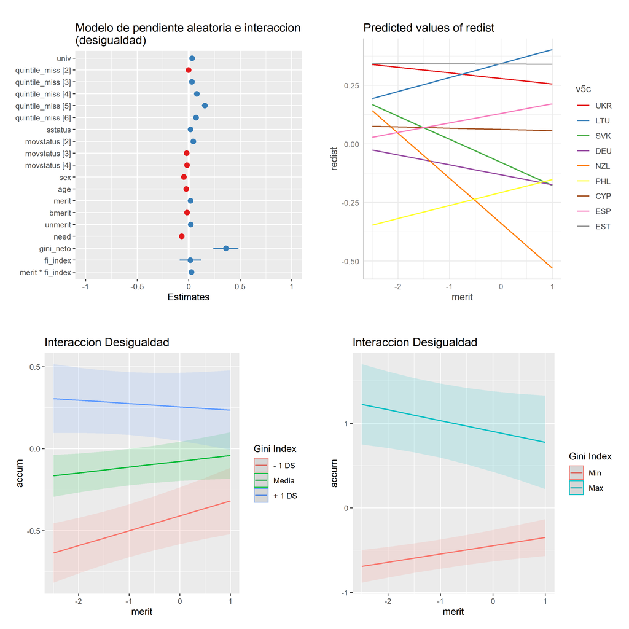

```r
results_3_accum_macro_bvi_efect <- sjPlot::plot_model(results_3_accum_macro_bvi, type="std", title = "Modelo de pendiente aleatoria e interaccion (desigualdad)")
ggsave(results_3_accum_macro_bvi_efect, filename = "output/results/results_3_accum_macro_bvi_efect.png", width = 10, height = 10, dpi= "retina")


graf2=ggpredict(results_2_accum_macro_bv, terms = c("merit","v5c [sample = 9]"), type="re")
pendientealeatoria_accum <- plot(graf2)
ggsave(pendientealeatoria_accum, filename = "output/results/pendientealeatoria_accum.png", width = 10, height = 10, dpi= "retina")


mer_accum_int_f1 <- sjPlot::plot_model(results_3_accum_macro_bvi_2, type = c("int"), title = "Interaccion Desigualdad",  mdrt.values = "meansd")+  scale_color_discrete("Gini Index", labels = c("- 1 DS", "Media", "+ 1 DS"))

mer_accum_int_f2 <- sjPlot::plot_model(results_3_accum_macro_bvi_2, type = c("int"), title = "Interaccion Desigualdad") +  scale_color_discrete("Gini Index", labels = c("Min", "Max"))


ggsave(mer_accum_int_f1, filename = "output/results/mer_accum_int_f1.png", width = 10, height = 10, dpi= "retina")


ggsave(plot_grid(list(results_3_accum_macro_bvi_efect, pendiente_aleatoria_redistbv,mer_accum_int_f1, mer_accum_int_f2) ,margin = c(0.5,0.5,0.5,0.5), tags = c(" ", " "," ", " ")), filename = "output/results/results_3_accum_macro_bvi_interacgini.png", width = 10, height = 10, dpi= "retina")
```

Segun la interaccion, podemos decir que el discursos meritocratico permite justifica r la desigual participacion de derechos basicos como la salud y la educaiccion, pero solo en contextos con una baja desigualdad. En paises con una alta desigualdad, la percepcion de meritocracia no fomenta la justificacion del acceso desigual a servicios basicos, lo cual hipotetiso que puede deberse a las diferencias redicales entre los servicios de alto y bajo costo, diferencias que por sus consecuencias no permiten justificar el acceso desigual ni si quiera considerando las diferencias de merito.

```r
# guardar tablas


#redis
save(results_1_redist_macro, file = "output/results/results_1_redist_macro.rdata")
save(results_2_redist_macro_bv, file = "output/results/results_2_redist_macro_bv.rdata")
save(results_3_redist_macro_bvi, file = "output/results/results_3_redist_macro_bvi.rdata")


#accum
save(results_1_accum_macro, file = "output/results/results_1_accum_macro.rdata")
save(results_2_accum_macro_bv, file = "output/results/results_2_accum_macro_bv.rdata")
save(results_3_accum_macro_bvi, file = "output/results/results_3_accum_macro_bvi.rdata")
```

# 5 Analisis de robustes Modelos Multinivel

## 5.1 Regresiones finales sin paises en los que no comverge el modelo de medida.

```r
mer_pref_sinnonconvr<- mer_pref[which(mer_pref$v5c!='VEN'), ]
mer_pref_sinnonconvr<- mer_pref_sinnonconvr[which(mer_pref_sinnonconvr$v5!=191), ]
mer_pref_sinnonconvr <- mer_pref_sinnonconvr[which(mer_pref_sinnonconvr$v5c!='CYP'), ]
mer_pref_sinnonconvr <- mer_pref_sinnonconvr[which(mer_pref_sinnonconvr$v5!=380), ]
mer_pref_sinnonconvr <- mer_pref_sinnonconvr[which(mer_pref_sinnonconvr$v5!=428), ]

results_3_redist_macro_bvi_nocong = lmer(redist ~ univ + as.factor(quintile_miss) +    sstatus + as.factor(movstatus) + sex + age  + merit + bmerit + unmerit + need + merit*gini_neto + fi_index + 1 +  (1 + merit| v5c), data = mer_pref_sinnonconvr, REML=F)

results_3_accum_macro_bvi_nocong = lmer(accum ~ univ + as.factor(quintile_miss) +  sstatus + as.factor(movstatus) + sex + age  + merit + bmerit + unmerit + need +  gini_neto + merit*fi_index + 1 +  (1 + merit| v5c), data = mer_pref_sinnonconvr, REML=F)
```

```r
htmlreg(list(results_3_redist_macro_bvi, results_3_redist_macro_bvi_nocong, results_3_accum_macro_bvi, results_3_accum_macro_bvi_nocong), caption = "Comparison model excludig countries non convergent in the measurement", custom.model.names = c("Whit", "Whithout","Whit", "Whithout"), custom.header = list("Redistribution" = 1:2, "Accumulation" = 3:4), star.symbol = "\\*", custom.note = "$***p <$ 0.001, $**p <$ 0.01, $*p <$ 0.05 <br> countries non convergent in the measurement model:Venezuela, Croatia, Cyprus, Italy, Latvia", custom.coef.names = c("Intercept", "University. Ed.", "Quintile 2", "Quintile 3", "Quintile 4","Quintile 5", "Quintile miss", "Subjetive status", "Subjetive upward mobility", "Supjetive downward mobility","Subjetive non-mobility","Gender", "Age", "Meritorcatic perception", "Meritocratic preferences", "Unmeritocratic perception", "Unmeritocratic preferences", "Gini index", "Economic freedom index", "Merit-perception x Gini", "Merit-perception x Economic-freedom"), caption.above = T)
```

Comparison model excludig countries non convergent in the measurement

|  | Redistribution Whit | Redistribution Whithout | Accumulation Whit | Accumulation Whithout |
| --- | --- | --- | --- | --- |
| Intercept | 0.87* | 1.21* | -1.73* | -2.39** |
|  | (0.39) | (0.48) | (0.75) | (0.92) |
| University. Ed. | -0.08*** | -0.08*** | 0.10*** | 0.10*** |
|  | (0.01) | (0.01) | (0.01) | (0.01) |
| Quintile 2 | -0.03** | -0.03** | -0.00 | 0.00 |
|  | (0.01) | (0.01) | (0.01) | (0.02) |
| Quintile 3 | -0.06*** | -0.06*** | 0.03* | 0.03 |
|  | (0.01) | (0.01) | (0.01) | (0.02) |
| Quintile 4 | -0.10*** | -0.10*** | 0.09*** | 0.08*** |
|  | (0.01) | (0.01) | (0.01) | (0.02) |
| Quintile 5 | -0.18*** | -0.18*** | 0.17*** | 0.16*** |
|  | (0.01) | (0.01) | (0.02) | (0.02) |
| Quintile miss | -0.12*** | -0.12*** | 0.08*** | 0.07*** |
|  | (0.01) | (0.01) | (0.02) | (0.02) |
| Subjetive status | -0.00*** | -0.00*** | 0.00*** | 0.00*** |
|  | (0.00) | (0.00) | (0.00) | (0.00) |
| Subjetive upward mobility | -0.01 | -0.00 | 0.05*** | 0.05*** |
|  | (0.01) | (0.01) | (0.01) | (0.01) |
| Supjetive downward mobility | 0.03*** | 0.03*** | -0.02 | -0.02 |
|  | (0.01) | (0.01) | (0.01) | (0.01) |
| Subjetive non-mobility | 0.00 | 0.02 | -0.02 | -0.01 |
|  | (0.01) | (0.01) | (0.02) | (0.02) |
| Gender | 0.04*** | 0.04*** | -0.11*** | -0.11*** |
|  | (0.01) | (0.01) | (0.01) | (0.01) |
| Age | 0.00*** | 0.00*** | -0.00*** | -0.00*** |
|  | (0.00) | (0.00) | (0.00) | (0.00) |
| Meritorcatic perception | -0.32*** | -0.36*** | -0.63** | -0.74** |
|  | (0.09) | (0.08) | (0.19) | (0.27) |
| Meritocratic preferences | 0.04*** | 0.04*** | -0.04*** | -0.04** |
|  | (0.01) | (0.01) | (0.01) | (0.01) |
| Unmeritocratic perception | 0.06*** | 0.07*** | 0.03*** | 0.04*** |
|  | (0.01) | (0.01) | (0.01) | (0.01) |
| Unmeritocratic preferences | 0.14*** | 0.14*** | -0.10*** | -0.10*** |
|  | (0.00) | (0.00) | (0.01) | (0.01) |
| Gini index | -0.01 | -0.01 | 0.05*** | 0.05*** |
|  | (0.01) | (0.00) | (0.01) | (0.01) |
| Economic freedom index | -0.08 | -0.13* | 0.03 | 0.12 |
|  | (0.04) | (0.06) | (0.09) | (0.11) |
| Merit-perception x Gini | 0.01** | 0.01*** |  |  |
|  | (0.00) | (0.00) |  |  |
| Merit-perception x Economic-freedom |  |  | 0.09*** | 0.11** |
|  |  |  | (0.03) | (0.04) |
| AIC | 90600.09 | 82324.89 | 146875.94 | 132953.40 |
| BIC | 90813.02 | 82535.32 | 147088.87 | 133163.83 |
| Log Likelihood | -45276.04 | -41138.44 | -73413.97 | -66452.70 |
| Num. obs. | 52681 | 47474 | 52681 | 47474 |
| Num. groups: v5c | 40 | 35 | 40 | 35 |
| Var: v5c (Intercept) | 0.05 | 0.04 | 0.13 | 0.12 |
| Var: v5c merit | 0.01 | 0.01 | 0.01 | 0.01 |
| Cov: v5c (Intercept) merit | 0.02 | 0.01 | 0.02 | 0.02 |
| Var: Residual | 0.32 | 0.33 | 0.95 | 0.96 |

$***p <$ 0.001, $**p <$ 0.01, $*p <$ 0.05 countries non convergent in the measurement model:Venezuela, Croatia, Cyprus, Italy, Latvia

Como puede apresiarce en las regresiones, los pesos de las distintas variables y su significacion no varian sustantivamente al excluir del calculo a los paises que no convergen en los modelos de medida.

## 5.2 Casos influyentes

### 5.2.1 Cook Distance

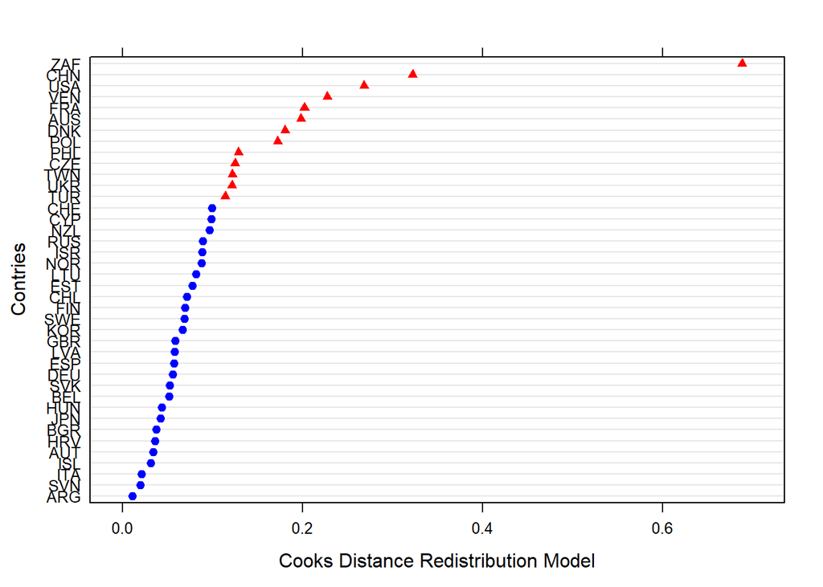

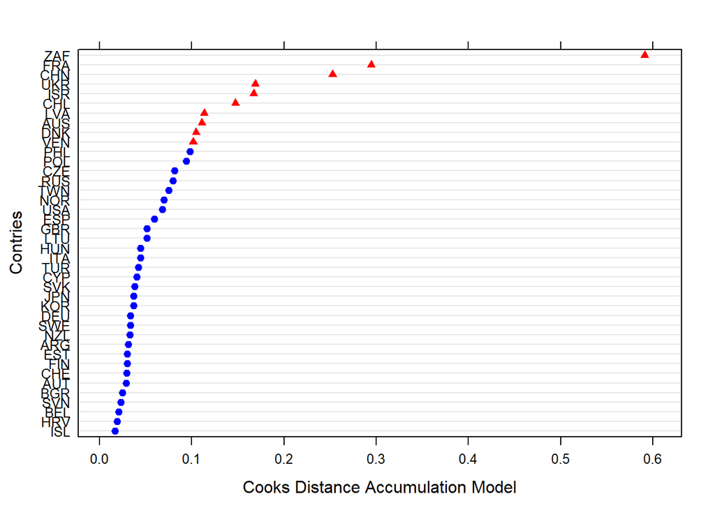

D de Cook

```r
#Redis
estex.m23_2a <- influence.ME::influence(results_3_redist_macro_bvi, "v5c")

plota <- plot(estex.m23_2a, which="cook",
     cutoff=.1, sort=TRUE,
     xlab="Cooks Distance Redistribution Model",
     ylab="Contries")

estex.m23_2b <-  influence.ME::influence(results_3_accum_macro_bvi, "v5c")

 plotb <-plot(estex.m23_2b, which="cook",
     cutoff=.1, sort=TRUE,
     xlab="Cooks Distance Accumulation Model",
     ylab="Contries")
```

cut point > 0.1 (4/40)

### 5.2.2 Comparació de los modelos expcluyendo casos influyentes a nivel 2

```r
mer_pref_sininfl <- mer_pref[which(mer_pref$v5c!='ZAF'), ]
mer_pref_sininfl <- mer_pref_sininfl[which(mer_pref_sininfl$v5c!='CYP'), ]
mer_pref_sininfl <- mer_pref_sininfl[which(mer_pref_sininfl$v5c!='TUR'), ]
mer_pref_sininfl <- mer_pref_sininfl[which(mer_pref_sininfl$v5c!='TWN'), ]
mer_pref_sininfl <- mer_pref_sininfl[which(mer_pref_sininfl$v5c!='UKR'), ]
mer_pref_sininfl <- mer_pref_sininfl[which(mer_pref_sininfl$v5c!='CZE'), ]
mer_pref_sininfl <- mer_pref_sininfl[which(mer_pref_sininfl$v5c!='FRA'), ]
mer_pref_sininfl <- mer_pref_sininfl[which(mer_pref_sininfl$v5c!='AUS'), ]
mer_pref_sininfl <- mer_pref_sininfl[which(mer_pref_sininfl$v5c!='DNK'), ]
mer_pref_sininfl <- mer_pref_sininfl[which(mer_pref_sininfl$v5c!='USA'), ]
mer_pref_sininfl <- mer_pref_sininfl[which(mer_pref_sininfl$v5c!='VEN'), ]
mer_pref_sininfl <- mer_pref_sininfl[which(mer_pref_sininfl$v5c!='PHL'), ]
mer_pref_sininfl <- mer_pref_sininfl[which(mer_pref_sininfl$v5c!='POL'), ]
mer_pref_sininfl <- mer_pref_sininfl[which(mer_pref_sininfl$v5c!='CHN'), ]

results_3_redist_macro_bvi_sininf = lmer(redist ~ univ + as.factor(quintile_miss) + sstatus + as.factor(movstatus) + sex + age  + merit + bmerit + unmerit + need + merit*gini_neto + fi_index + 1 +  (1 + merit| v5c), data = mer_pref_sininfl, REML=F)



mer_pref_sininfl <- mer_pref[which(mer_pref$v5c!='ZAF'), ]
mer_pref_sininfl <- mer_pref_sininfl[which(mer_pref_sininfl$v5c!='VEN'), ]
mer_pref_sininfl <- mer_pref_sininfl[which(mer_pref_sininfl$v5c!='FRA'), ]
mer_pref_sininfl <- mer_pref_sininfl[which(mer_pref_sininfl$v5c!='CHN'), ]
mer_pref_sininfl <- mer_pref_sininfl[which(mer_pref_sininfl$v5c!='UKR'), ]
mer_pref_sininfl <- mer_pref_sininfl[which(mer_pref_sininfl$v5c!='ISR'), ]
mer_pref_sininfl <- mer_pref_sininfl[which(mer_pref_sininfl$v5c!='CHL'), ]
mer_pref_sininfl <- mer_pref_sininfl[which(mer_pref_sininfl$v5c!='AUS'), ]
mer_pref_sininfl <- mer_pref_sininfl[which(mer_pref_sininfl$v5c!='DNK'), ]
mer_pref_sininfl <- mer_pref_sininfl[which(mer_pref_sininfl$v5c!='LVA'), ]
mer_pref_sininfl <- mer_pref_sininfl[which(mer_pref_sininfl$v5c!='VEN'), ]
mer_pref_sininfl <- mer_pref_sininfl[which(mer_pref_sininfl$v5c!='PHL'), ]
mer_pref_sininfl <- mer_pref_sininfl[which(mer_pref_sininfl$v5c!='POL'), ]
mer_pref_sininfl <- mer_pref_sininfl[which(mer_pref_sininfl$v5c!='CZE'), ]


results_3_accum_macro_bvi_sininfl = lmer(accum ~ univ + as.factor(quintile_miss) +  sstatus + as.factor(movstatus) + sex + age  + merit + bmerit + unmerit + need +  gini_neto + merit*fi_index + 1 +  (1 + merit| v5c), data = mer_pref_sininfl, REML=F)
```

```r
htmlreg(list(results_3_redist_macro_bvi, results_3_redist_macro_bvi_sininf,results_3_accum_macro_bvi, results_3_accum_macro_bvi_sininfl), caption = "Comparison model Without influential cases in level two", custom.model.names = c("Whit", "Whithout","Whit", "Whithout"), custom.header = list("Redistribution" = 1:2, "Accumulation" = 3:4), caption.above = T, star.symbol = "\\*", custom.note = "$***p <$ 0.001, $**p <$ 0.01, $*p <$ 0.05 <br> Influential contries: CYP, TUR, TWN, UKR,CZE, FRA, AUS, DNK, USA, VEN,PHL, POL, CHN, ISR, CHL, LVA, PHL", custom.coef.names = c("Intercept", "University. Ed.", "Quintile 2", "Quintile 3", "Quintile 4","Quintile 5", "Quintile miss", "Subjetive status", "Subjetive upward mobility", "Supjetive downward mobility" ,"Subjetive non-mobility","Gender", "Age", "Meritorcatic perception", "Meritocratic preferences", "Unmeritocratic perception", "Unmeritocratic preferences", "Gini index", "Economic freedom index", "Merit-perception x Gini", "Merit-perception x Economic-freedom"))
```

Comparison model Without influential cases in level two

|  | Redistribution Whit | Redistribution Whithout | Accumulation Whit | Accumulation Whithout |
| --- | --- | --- | --- | --- |
| Intercept | 0.87* | 1.04* | -1.73* | -4.71*** |
|  | (0.39) | (0.51) | (0.75) | (1.01) |
| University. Ed. | -0.08*** | -0.09*** | 0.10*** | 0.10*** |
|  | (0.01) | (0.01) | (0.01) | (0.01) |
| Quintile 2 | -0.03** | -0.02 | -0.00 | -0.04 |
|  | (0.01) | (0.01) | (0.01) | (0.02) |
| Quintile 3 | -0.06*** | -0.05*** | 0.03* | 0.02 |
|  | (0.01) | (0.01) | (0.01) | (0.02) |
| Quintile 4 | -0.10*** | -0.11*** | 0.09*** | 0.09*** |
|  | (0.01) | (0.01) | (0.01) | (0.02) |
| Quintile 5 | -0.18*** | -0.19*** | 0.17*** | 0.15*** |
|  | (0.01) | (0.01) | (0.02) | (0.02) |
| Quintile miss | -0.12*** | -0.10*** | 0.08*** | 0.07*** |
|  | (0.01) | (0.01) | (0.02) | (0.02) |
| Subjetive status | -0.00*** | -0.00*** | 0.00*** | 0.00** |
|  | (0.00) | (0.00) | (0.00) | (0.00) |
| Subjetive upward mobility | -0.01 | -0.01 | 0.05*** | 0.03* |
|  | (0.01) | (0.01) | (0.01) | (0.01) |
| Supjetive downward mobility | 0.03*** | 0.03** | -0.02 | -0.03 |
|  | (0.01) | (0.01) | (0.01) | (0.02) |
| Subjetive non-mobility | 0.00 | 0.01 | -0.02 | -0.02 |
|  | (0.01) | (0.01) | (0.02) | (0.02) |
| Gender | 0.04*** | 0.06*** | -0.11*** | -0.10*** |
|  | (0.01) | (0.01) | (0.01) | (0.01) |
| Age | 0.00*** | 0.00*** | -0.00*** | -0.00*** |
|  | (0.00) | (0.00) | (0.00) | (0.00) |
| Meritorcatic perception | -0.32*** | -0.37*** | -0.63** | -0.80* |
|  | (0.09) | (0.11) | (0.19) | (0.33) |
| Meritocratic preferences | 0.04*** | 0.04*** | -0.04*** | -0.08*** |
|  | (0.01) | (0.01) | (0.01) | (0.02) |
| Unmeritocratic perception | 0.06*** | 0.06*** | 0.03*** | 0.01 |
|  | (0.01) | (0.01) | (0.01) | (0.01) |
| Unmeritocratic preferences | 0.14*** | 0.16*** | -0.10*** | -0.10*** |
|  | (0.00) | (0.01) | (0.01) | (0.01) |
| Gini index | -0.01 | -0.00 | 0.05*** | 0.05*** |
|  | (0.01) | (0.01) | (0.01) | (0.01) |
| Economic freedom index | -0.08 | -0.14* | 0.03 | 0.42*** |
|  | (0.04) | (0.06) | (0.09) | (0.12) |
| Merit-perception x Gini | 0.01** | 0.01** |  |  |
|  | (0.00) | (0.00) |  |  |
| Merit-perception x Economic-freedom |  |  | 0.09*** | 0.12** |
|  |  |  | (0.03) | (0.04) |
| AIC | 90600.09 | 46577.65 | 146875.94 | 83785.10 |
| BIC | 90813.02 | 46775.62 | 147088.87 | 83984.99 |
| Log Likelihood | -45276.04 | -23264.82 | -73413.97 | -41868.55 |
| Num. obs. | 52681 | 28253 | 52681 | 30599 |
| Num. groups: v5c | 40 | 26 | 40 | 27 |
| Var: v5c (Intercept) | 0.05 | 0.03 | 0.13 | 0.08 |
| Var: v5c merit | 0.01 | 0.01 | 0.01 | 0.01 |
| Cov: v5c (Intercept) merit | 0.02 | 0.01 | 0.02 | 0.01 |
| Var: Residual | 0.32 | 0.30 | 0.95 | 0.90 |

Al excluir los casos influyentes la mayoria de las variable no cambia drasticamente significaciones ni sentidos. La variable fi_index pasa a ser significativa. A mayor libertad economica menor preferencia redistributiva.